# Spotify API exploration

```python
import numpy as np
import pandas as pd
import matplotlib.pyplot as plt
import spotipy
import config
```

this is how to set environment variables in a jupyter notebook

```python
#%env MY_VAR=MY_VALUE
```

```python
print(type(config.SPOTIFY_CLIENT_ID))
```

```
<class 'str'>
```

```python
import spotipy
from spotipy.oauth2 import SpotifyClientCredentials

sp = spotipy.Spotify(auth_manager=SpotifyClientCredentials(client_id=config.SPOTIFY_CLIENT_ID,
                                                           client_secret=config.SPOTIFY_SECRET))

results = sp.search(q='lil baby', limit=20)
for idx, track in enumerate(results['tracks']['items']):
    print(idx, track['name'])
```

```
0 Pure Cocaine
1 Drip Too Hard (Lil Baby & Gunna)
2 Freestyle
3 Wants and Needs (feat. Lil Baby)
4 Yes Indeed
5 On Me
6 In A Minute
7 Baby (Lil Baby feat. DaBaby)
8 EVERY CHANCE I GET (feat. Lil Baby & Lil Durk)
9 Sleazy Flow (with Lil Baby) - Remix
10 Emotionally Scarred
11 Heyy
12 Forever (feat. Fridayy)
13 California Breeze
14 The World Is Yours To Take - Budweiser Anthem Of The FIFA World Cup 2022
15 Not Finished
16 STAYING ALIVE (feat. Drake & Lil Baby)
17 Real Spill
18 Frozen
19 Detox
```

Get a playlist of mine  
can just retrieve playlist with the link

## idea here is to look at a playlist that the user provides

```python
results = sp.playlist('https://open.spotify.com/playlist/3LNpCyZZnzP0YQDLC52CKS?si=81c062b03e8447b1')
```

```python
print(results)
```

```
{'collaborative': False, 'description': '', 'external_urls': {'spotify': 'https://open.spotify.com/playlist/3LNpCyZZnzP0YQDLC52CKS'}, 'followers': {'href': None, 'total': 1}, 'href': 'https://api.spotify.com/v1/playlists/3LNpCyZZnzP0YQDLC52CKS?additional_types=track', 'id': '3LNpCyZZnzP0YQDLC52CKS',…
```

```python
results.keys()
```

```
dict_keys(['collaborative', 'description', 'external_urls', 'followers', 'href', 'id', 'images', 'name', 'owner', 'primary_color', 'public', 'snapshot_id', 'tracks', 'type', 'uri'])
```

```python
print(results['external_urls'])
```

```
{'spotify': 'https://open.spotify.com/playlist/3LNpCyZZnzP0YQDLC52CKS'}
```

```python
results['href']
```

```
'https://api.spotify.com/v1/playlists/3LNpCyZZnzP0YQDLC52CKS?additional_types=track'
```

```python
import json
```

```python
print(json.dumps(results, indent=2, default=str))
```

[output not shown]

[output cut: 18817 more lines]

[output not shown]

```python
print (json.dumps(results["tracks"]["items"], indent=2, default=str))
```

[output not shown]

[output cut: 18763 more lines]

[output not shown]

This the names of all of the tracks in the playlist

```python
res = results["tracks"]["items"]

playlist_df = pd.DataFrame(columns=['song_title', 'artist','artist_id' ,'album', 'track_id', 'popularity'], index=None)
track_position = 1
for i in res:
    track = i["track"]
#    print(i, end='')
#    print(i.keys())
#    print(track)
    name = track["name"]
    #we should get track ID

    artists = []
    artist_list = track["artists"]
    for a in range(len(artist_list)):
        artists.append((artist_list[a]['name'], artist_list[a]['id']))
        #at this level we can grab artist ID as well




    album = track["album"]["name"]
    #should be able to grab album ID as well
    track_id = track["id"]
    artist_list = [x[0] for x in artists]
    artist_id_list = [x[1] for x in artists]

    #track popularity?
    track_pop = track["popularity"]



    print('name:', name)
    print('artist:', artists)
    print('album:', album)
    print('artist_ids:', artist_id_list)
    print('popularity', track_pop)
    print("-------------------------------")

#     artist_id_list = [x[1] for x in artists]


    playlist_df.loc[track_position] = {'song_title' : name,
                                   'artist' : artist_list,
                                   'artist_id' : artist_id_list,
                                   'album' : album,
                                   'track_id' : track_id,
                                    'popularity':track_pop} #can i put a list into one column?
    track_position+=1
```

```
name: Hell Of A Night
artist: [('ScHoolboy Q', '5IcR3N7QB1j6KBL8eImZ8m')]
album: Oxymoron (Deluxe)
artist_ids: ['5IcR3N7QB1j6KBL8eImZ8m']
popularity 59
-------------------------------
name: Drug Dealers Anonymous
artist: [('Pusha T', '0ONHkAv9pCAFxb0zJwDNTy'), ('JAY-Z', '3nFkdlSjzX9mRTtwJOzDYB')]
album: Drug Dealers Anonymous
artist_ids: ['0ONHkAv9pCAFxb0zJwDNTy', '3nFkdlSjzX9mRTtwJOzDYB']
popularity 53
-------------------------------
name: Money Made Me Do It
artist: [('Post Malone', '246dkjvS1zLTtiykXe5h60'), ('2 Chainz', '17lzZA2AlOHwCwFALHttmp')]
album: Stoney (Deluxe)
artist_ids: ['246dkjvS1zLTtiykXe5h60', '17lzZA2AlOHwCwFALHttmp']
popularity 60
-------------------------------
name: Lookin
artist: [('Playboi Carti', '699OTQXzgjhIYAHMy9RyPD'), ('Lil Uzi Vert', '4O15NlyKLIASxsJ0PrXPfz')]
album: Playboi Carti
artist_ids: ['699OTQXzgjhIYAHMy9RyPD', '4O15NlyKLIASxsJ0PrXPfz']
popularity 58
-------------------------------
name: Let It Go
artist: [('Playboi Carti', '699OTQXzgjhIYAHMy9RyPD')]
album: Playboi Carti
artist_ids: ['699OTQXzgjhIYAHMy9RyPD']
popularity 64
-------------------------------
name: NO. 9
artist: [('Playboi Carti', '699OTQXzgjhIYAHMy9RyPD')]
album: Playboi Carti
artist_ids: ['699OTQXzgjhIYAHMy9RyPD']
popularity 62
-------------------------------
name: Amen (feat. Drake)
artist: [('Meek Mill', '20sxb77xiYeusSH8cVdatc'), ('Drake', '3TVXtAsR1Inumwj472S9r4')]
album: Dreams and Nightmares (Deluxe Edition)
artist_ids: ['20sxb77xiYeusSH8cVdatc', '3TVXtAsR1Inumwj472S9r4']
```

[output cut: 221 more lines]

```
artist_ids: ['0QHgL1lAIqAw0HtD7YldmP', '62vbsDRAq0qHdezaCOzB0T', '5pKCCKE2ajJHZ9KAiaK11H', '2EMAnMvWE2eb56ToJVfCWs']
popularity 44
-------------------------------
name: Did You See - French Montana Remix
artist: [('J Hus', '2a0uxJgbvvIRI4GX8pYfcr'), ('French Montana', '6vXTefBL93Dj5IqAWq6OTv')]
album: Did You See (French Montana Remix)
artist_ids: ['2a0uxJgbvvIRI4GX8pYfcr', '6vXTefBL93Dj5IqAWq6OTv']
popularity 36
-------------------------------
name: Neck And Neck - DNMO Remix
artist: [('Zeds Dead', '67qogtRNI0GjUr8PlaG6Zh'), ('Dragonette', '4GLJPBj5Cdr9AgLKvLWM4n'), ('DNMO', '3cMInYqk6yzf37zo8iznoz')]
album: Northern Lights (Remixes)
artist_ids: ['67qogtRNI0GjUr8PlaG6Zh', '4GLJPBj5Cdr9AgLKvLWM4n', '3cMInYqk6yzf37zo8iznoz']
popularity 58
-------------------------------
```

```python
playlist_df
```

|  | song_title | artist | artist_id | album | track_id | popularity |
| --- | --- | --- | --- | --- | --- | --- |
| 1 | Hell Of A Night | [ScHoolboy Q] | [5IcR3N7QB1j6KBL8eImZ8m] | Oxymoron (Deluxe) | 5DOR49R0fehoBmyNL8m4sN | 59 |
| 2 | Drug Dealers Anonymous | [Pusha T, JAY-Z] | [0ONHkAv9pCAFxb0zJwDNTy, 3nFkdlSjzX9mRTtwJOzDYB] | Drug Dealers Anonymous | 1b6rmL3VXBgYTbn61kM8wT | 53 |
| 3 | Money Made Me Do It | [Post Malone, 2 Chainz] | [246dkjvS1zLTtiykXe5h60, 17lzZA2AlOHwCwFALHttmp] | Stoney (Deluxe) | 1ysAvOdJgUjc6CqOQxepaz | 60 |
| 4 | Lookin | [Playboi Carti, Lil Uzi Vert] | [699OTQXzgjhIYAHMy9RyPD, 4O15NlyKLIASxsJ0PrXPfz] | Playboi Carti | 1UAmQe8EwpxQ80OfYVD13z | 58 |
| 5 | Let It Go | [Playboi Carti] | [699OTQXzgjhIYAHMy9RyPD] | Playboi Carti | 23QyE9GQpXsX9WgEDADMa6 | 64 |
| 6 | NO. 9 | [Playboi Carti] | [699OTQXzgjhIYAHMy9RyPD] | Playboi Carti | 5Nq6lLSxphlsA6nQB0KtES | 62 |
| 7 | Amen (feat. Drake) | [Meek Mill, Drake] | [20sxb77xiYeusSH8cVdatc, 3TVXtAsR1Inumwj472S9r4] | Dreams and Nightmares (Deluxe Edition) | 32UIpKdyGzgTPTO8e5ge5c | 50 |
| 8 | Litty (feat. Tory Lanez) | [Meek Mill, Sound M.O.B., Tory Lanez] | [20sxb77xiYeusSH8cVdatc, 4yLuE0l9rK7fqijTb7BPh... | DC4 | 5J5PXmMdQ2nh1lZOal8KmK | 61 |
| 9 | Offended (feat. Young Thug & 21 Savage) | [Meek Mill, Young Thug, 21 Savage] | [20sxb77xiYeusSH8cVdatc, 50co4Is1HCEo8bhOyUWKp... | DC4 | 40WxFAbt8UEK7jKLmIxRNY | 55 |
| 10 | Hoes | [Lil Wayne, Mannie Fresh] | [55Aa2cqylxrFIXC767Z865, 0fbFfVckGKsDbAfYnB5mD1] | Tha Carter | 6EQxuF78fy2hy1sIW2SDiQ | 41 |
| 11 | Mo Fire | [Lil Wayne] | [55Aa2cqylxrFIXC767Z865] | Tha Carter II | 6C5hEhWg9UUPaxdmXQUjeq | 47 |
| 12 | Hustler Musik | [Lil Wayne] | [55Aa2cqylxrFIXC767Z865] | Tha Carter II | 2334WaCjswLcRIRgTTPWaZ | 59 |
| 13 | Mr. Carter | [Lil Wayne, JAY-Z] | [55Aa2cqylxrFIXC767Z865, 3nFkdlSjzX9mRTtwJOzDYB] | Tha Carter III | 2tQM1BUrXp2kqOM6mN11TC | 58 |
| 14 | A Milli | [Lil Wayne] | [55Aa2cqylxrFIXC767Z865] | Tha Carter III | 6ScJMrlpiLfZUGtWp4QIVt | 69 |
| 15 | Mrs. Officer | [Lil Wayne, Bobby V., Kidd Kidd] | [55Aa2cqylxrFIXC767Z865, 4HgF4KnohByNElYid7iCN... | Tha Carter III | 0EHR9OObFtjlhQB8wSt1m7 | 66 |
| 16 | Sauce It Up | [Lil Uzi Vert] | [4O15NlyKLIASxsJ0PrXPfz] | Luv Is Rage 2 | 1uL78kFWxhz3umTMWJu8n5 | 66 |
| 17 | Seven Million (feat. Future) | [Lil Uzi Vert, Future] | [4O15NlyKLIASxsJ0PrXPfz, 1RyvyyTE3xzB2ZywiAwp0i] | The Perfect LUV Tape | 6j0teRL3WdExzqmy334sh5 | 59 |
| 18 | You Was Right | [Lil Uzi Vert] | [4O15NlyKLIASxsJ0PrXPfz] | Lil Uzi Vert vs. The World | 2ANLarE8yHVsLWW21nj79M | 67 |
| 19 | Ps & Qs | [Lil Uzi Vert] | [4O15NlyKLIASxsJ0PrXPfz] | Lil Uzi Vert vs. The World | 1gGsNNUfvVMOv4llVMg8Vg | 65 |
| 20 | Top | [Lil Uzi Vert] | [4O15NlyKLIASxsJ0PrXPfz] | Luv Is Rage | 55Q46o5adtSobImSKrrlqW | 64 |
| 21 | Lay Up | [Future] | [1RyvyyTE3xzB2ZywiAwp0i] | Beast Mode | 5VnyRfL844Th0BBBGnhJOL | 0 |
| 22 | One Hunnid Racks | [Future, Drake] | [1RyvyyTE3xzB2ZywiAwp0i, 3TVXtAsR1Inumwj472S9r4] | Esco Terrestrial | 57wUi9MWkuv5pmVU954OJe | 0 |
| 23 | Jumpman | [Drake, Future] | [3TVXtAsR1Inumwj472S9r4, 1RyvyyTE3xzB2ZywiAwp0i] | What A Time To Be Alive | 27GmP9AWRs744SzKcpJsTZ | 71 |
| 24 | Low Life (feat. The Weeknd) | [Future, The Weeknd] | [1RyvyyTE3xzB2ZywiAwp0i, 1Xyo4u8uXC1ZmMpatF05PJ] | EVOL | 7EiZI6JVHllARrX9PUvAdX | 74 |
| 25 | March Madness | [Future] | [1RyvyyTE3xzB2ZywiAwp0i] | March Madness | 6hVGw7yVUd2bpdHMPCWrtN | 0 |
| 26 | PICK IT UP (feat. A$AP Rocky) | [Famous Dex, A$AP Rocky] | [0WOxhx4hikIsyF3CRPLC8W, 13ubrt8QOOCPljQ2FL1Kca] | Pick It Up (feat. A$AP Rocky) | 3ncgNpxLoBQ65ABk4djDyd | 64 |
| 27 | Modern Slavery | [Huncho Jack, Travis Scott, Quavo] | [6extd4B6hl8VTmnlhpl2bY, 0Y5tJX1MQlPlqiwlOH1tJ... | Huncho Jack, Jack Huncho | 7J6bnDDitOwfelaJNixHhL | 58 |
| 28 | Upper Echelon (feat. T.I. & 2 Chainz) | [Travis Scott, T.I., 2 Chainz] | [0Y5tJX1MQlPlqiwlOH1tJY, 4OBJLual30L7gRl5UkeRc... | Upper Echelon (feat. T.I. & 2 Chainz) | 1x6Zk7hoTIlSOFNZnyxjZD | 55 |
| 29 | Sloppy Toppy ft. Migos Pewee Longway | [Travi$ Scott] | [None] | Days Before Rodeo | None | 0 |
| 30 | Mamacita (feat. Rich Homie Quan & Young Thug) | [Travis Scott, Rich Homie Quan, Young Thug] | [0Y5tJX1MQlPlqiwlOH1tJY, 5lHRUCqkQZCIWeX7xG4sY... | Mamacita (feat. Rich Homie Quan & Young Thug) | 3SEd8nPd8MpGwk6ZZ8tk2j | 64 |
| 31 | Antidote | [Travis Scott] | [0Y5tJX1MQlPlqiwlOH1tJY] | Rodeo (Expanded Edition) | 1wHZx0LgzFHyeIZkUydNXq | 72 |
| 32 | Wyclef Jean | [Young Thug] | [50co4Is1HCEo8bhOyUWKpn] | JEFFERY | 55OdqrG8WLmsYyY1jijD9b | 61 |
| 33 | Say A' | [A Boogie Wit da Hoodie] | [31W5EY0aAly4Qieq6OFu6I] | The Bigger Artist | 3AMnOVxEHUgVrythGgqPhI | 58 |
| 34 | Go Legend (& Metro Boomin) | [Big Sean, Metro Boomin, Travis Scott] | [0c173mlxpT3dSFRgMO8XPh, 0iEtIxbK0KxaSlF7G42ZO... | Double Or Nothing (& Metro Boomin) | 3wAI7MIQtTgwcRmwchPZBc | 56 |
| 35 | X (with 2 Chainz & Saudi) | [ScHoolboy Q, 2 Chainz, Saudi] | [5IcR3N7QB1j6KBL8eImZ8m, 17lzZA2AlOHwCwFALHttm... | Black Panther The Album Music From And Inspire... | 4LmAnpjlhWTahvRkYR8xJa | 65 |
| 36 | It's A Vibe | [2 Chainz, Ty Dolla $ign, Trey Songz, Jhené Aiko] | [17lzZA2AlOHwCwFALHttmp, 7c0XG5cIJTrrAgEC3ULPi... | Pretty Girls Like Trap Music | 6H0AwSQ20mo62jGlPGB8S6 | 68 |
| 37 | Frat Rules (feat. A$AP Rocky, Playboi Carti & ... | [A$AP Mob, A$AP Rocky, Playboi Carti, Big Sean] | [7yO4IdJjCEPz7YgZMe25iS, 13ubrt8QOOCPljQ2FL1Kc... | Cozy Tapes Vol. 2: Too Cozy | 0RyA3o15NOLJYtm9NlDu5c | 65 |
| 38 | Shooters | [Tory Lanez] | [2jku7tDXc6XoB6MO2hFuqg] | MEMORIES DON'T DIE | 6TrjaOqUwdKQ7KNxJr2s9Y | 57 |
| 39 | Can't C Me | [2Pac] | [1ZwdS5xdxEREPySFridCfh] | All Eyez On Me | 09EwNbGvUyu7BDEYG0cJro | 0 |
| 40 | One Foot | [21 Savage] | [1URnnhqYAYcrqrcwql10ft] | One Foot | 6fwX6ueeMZgT8LIsPthAnT | 28 |
| 41 | Bali (feat. Nav) | [88GLAM, NAV] | [2I9SLklAOG0vdMiUUMNxRl, 7rkW85dBwwrJtlHRDkJDAC] | 88glam | 3OJq3VFyNrU0INcTwPyjbD | 0 |
| 42 | Shake Down | [Akon] | [0z4gvV4rjIZ9wHck67ucSV] | Konvicted | 28keqzXW2FWH60oYvYRFAt | 0 |
| 43 | Look Alive (feat. Drake) | [BlocBoy JB, Drake] | [4TEJudQY2pXxVHPE3gD2EU, 3TVXtAsR1Inumwj472S9r4] | Look Alive (feat. Drake) | 4qKcDkK6siZ7Jp1Jb4m0aL | 74 |
| 44 | Wild Thoughts - Medasin Dance Remix | [DJ Khaled, Medasin, Rihanna, Bryson Tiller] | [0QHgL1lAIqAw0HtD7YldmP, 62vbsDRAq0qHdezaCOzB0... | Wild Thoughts (Medasin Dance Remix) | 4CANqU20rw8PXzYvocPzp7 | 44 |
| 45 | Did You See - French Montana Remix | [J Hus, French Montana] | [2a0uxJgbvvIRI4GX8pYfcr, 6vXTefBL93Dj5IqAWq6OTv] | Did You See (French Montana Remix) | 3XR1t5e2teHzxqEsY29D8n | 36 |
| 46 | Neck And Neck - DNMO Remix | [Zeds Dead, Dragonette, DNMO] | [67qogtRNI0GjUr8PlaG6Zh, 4GLJPBj5Cdr9AgLKvLWM4... | Northern Lights (Remixes) | 2bCjaF7cRm53Wdq9RtkYJu | 58 |

## Get audio features from songs on playlists

```python
#a list of all of the track ids in the playlist
tracklist = playlist_df.track_id.ravel()
tracklist
#tracklist[0]
```

```
array(['5DOR49R0fehoBmyNL8m4sN', '1b6rmL3VXBgYTbn61kM8wT',
       '1ysAvOdJgUjc6CqOQxepaz', '1UAmQe8EwpxQ80OfYVD13z',
       '23QyE9GQpXsX9WgEDADMa6', '5Nq6lLSxphlsA6nQB0KtES',
       '32UIpKdyGzgTPTO8e5ge5c', '5J5PXmMdQ2nh1lZOal8KmK',
       '40WxFAbt8UEK7jKLmIxRNY', '6EQxuF78fy2hy1sIW2SDiQ',
       '6C5hEhWg9UUPaxdmXQUjeq', '2334WaCjswLcRIRgTTPWaZ',
       '2tQM1BUrXp2kqOM6mN11TC', '6ScJMrlpiLfZUGtWp4QIVt',
       '0EHR9OObFtjlhQB8wSt1m7', '1uL78kFWxhz3umTMWJu8n5',
       '6j0teRL3WdExzqmy334sh5', '2ANLarE8yHVsLWW21nj79M',
       '1gGsNNUfvVMOv4llVMg8Vg', '55Q46o5adtSobImSKrrlqW',
       '5VnyRfL844Th0BBBGnhJOL', '57wUi9MWkuv5pmVU954OJe',
       '27GmP9AWRs744SzKcpJsTZ', '7EiZI6JVHllARrX9PUvAdX',
       '6hVGw7yVUd2bpdHMPCWrtN', '3ncgNpxLoBQ65ABk4djDyd',
       '7J6bnDDitOwfelaJNixHhL', '1x6Zk7hoTIlSOFNZnyxjZD', None,
       '3SEd8nPd8MpGwk6ZZ8tk2j', '1wHZx0LgzFHyeIZkUydNXq',
       '55OdqrG8WLmsYyY1jijD9b', '3AMnOVxEHUgVrythGgqPhI',
       '3wAI7MIQtTgwcRmwchPZBc', '4LmAnpjlhWTahvRkYR8xJa',
       '6H0AwSQ20mo62jGlPGB8S6', '0RyA3o15NOLJYtm9NlDu5c',
       '6TrjaOqUwdKQ7KNxJr2s9Y', '09EwNbGvUyu7BDEYG0cJro',
       '6fwX6ueeMZgT8LIsPthAnT', '3OJq3VFyNrU0INcTwPyjbD',
       '28keqzXW2FWH60oYvYRFAt', '4qKcDkK6siZ7Jp1Jb4m0aL',
       '4CANqU20rw8PXzYvocPzp7', '3XR1t5e2teHzxqEsY29D8n',
       '2bCjaF7cRm53Wdq9RtkYJu'], dtype=object)
```

```python
track_audio_features = sp.audio_analysis(tracklist[0])['track']
```

```python
#print(json.dumps(track_audio_features, indent=2, default=str))
```

```python
try:
    track_audio_features = sp.audio_features(tracklist)
    for feature in track_audio_features:
        print(json.dumps(feature, indent=4))
        print()
except AttributeError:
    null_song_idx = np.where(tracklist == None)
    pass

#drop songs that arent found in spotify
tracklist = [x for x in tracklist if (x != None)]

track_audio_features = sp.audio_features(tracklist)

# for feature in track_audio_features:
#     print(json.dumps(feature, indent=4))
#     print()
print('These are the songs which could not be analyzed. (this is probably because theyre not on spotify):\n', playlist_df.iloc[null_song_idx]["song_title"])
```

```
These are the songs which could not be analyzed. (this is probably because theyre not on spotify):
 29    Sloppy Toppy ft. Migos  Pewee Longway
Name: song_title, dtype: object
```

```python
features_df = pd.DataFrame()
i = 1
for audio_features in track_audio_features:
    song_features = pd.DataFrame(audio_features, index=[i])
#    print(audio_features.keys())
    features_df = pd.concat([features_df,song_features], axis=0)
    i+=1
features_df
```

|  | danceability | energy | key | loudness | mode | speechiness | acousticness | instrumentalness | liveness | valence | tempo | type | id | uri | track_href | analysis_url | duration_ms | time_signature |
| --- | --- | --- | --- | --- | --- | --- | --- | --- | --- | --- | --- | --- | --- | --- | --- | --- | --- | --- |
| 1 | 0.652 | 0.836 | 2 | -7.179 | 0 | 0.1530 | 0.37700 | 0.000000 | 0.1380 | 0.162 | 123.946 | audio_features | 5DOR49R0fehoBmyNL8m4sN | spotify:track:5DOR49R0fehoBmyNL8m4sN | https://api.spotify.com/v1/tracks/5DOR49R0feho... | https://api.spotify.com/v1/audio-analysis/5DOR... | 272453 | 4 |
| 2 | 0.558 | 0.864 | 11 | -5.100 | 1 | 0.4300 | 0.31800 | 0.000000 | 0.1230 | 0.474 | 152.804 | audio_features | 1b6rmL3VXBgYTbn61kM8wT | spotify:track:1b6rmL3VXBgYTbn61kM8wT | https://api.spotify.com/v1/tracks/1b6rmL3VXBgY... | https://api.spotify.com/v1/audio-analysis/1b6r... | 253787 | 4 |
| 3 | 0.734 | 0.429 | 7 | -6.511 | 1 | 0.1600 | 0.30500 | 0.000000 | 0.0659 | 0.372 | 83.021 | audio_features | 1ysAvOdJgUjc6CqOQxepaz | spotify:track:1ysAvOdJgUjc6CqOQxepaz | https://api.spotify.com/v1/tracks/1ysAvOdJgUjc... | https://api.spotify.com/v1/audio-analysis/1ysA... | 224960 | 4 |
| 4 | 0.827 | 0.570 | 0 | -8.220 | 1 | 0.3650 | 0.04570 | 0.000000 | 0.1480 | 0.412 | 148.119 | audio_features | 1UAmQe8EwpxQ80OfYVD13z | spotify:track:1UAmQe8EwpxQ80OfYVD13z | https://api.spotify.com/v1/tracks/1UAmQe8EwpxQ... | https://api.spotify.com/v1/audio-analysis/1UAm... | 183552 | 4 |
| 5 | 0.684 | 0.530 | 8 | -5.298 | 0 | 0.2860 | 0.00353 | 0.000000 | 0.5730 | 0.550 | 157.017 | audio_features | 23QyE9GQpXsX9WgEDADMa6 | spotify:track:23QyE9GQpXsX9WgEDADMa6 | https://api.spotify.com/v1/tracks/23QyE9GQpXsX... | https://api.spotify.com/v1/audio-analysis/23Qy... | 150410 | 4 |
| 6 | 0.885 | 0.607 | 1 | -7.642 | 0 | 0.3850 | 0.00973 | 0.000000 | 0.3250 | 0.391 | 137.887 | audio_features | 5Nq6lLSxphlsA6nQB0KtES | spotify:track:5Nq6lLSxphlsA6nQB0KtES | https://api.spotify.com/v1/tracks/5Nq6lLSxphls... | https://api.spotify.com/v1/audio-analysis/5Nq6... | 199191 | 4 |
| 7 | 0.503 | 0.795 | 10 | -4.505 | 1 | 0.3350 | 0.17800 | 0.000000 | 0.0420 | 0.265 | 149.981 | audio_features | 32UIpKdyGzgTPTO8e5ge5c | spotify:track:32UIpKdyGzgTPTO8e5ge5c | https://api.spotify.com/v1/tracks/32UIpKdyGzgT... | https://api.spotify.com/v1/audio-analysis/32UI... | 289707 | 4 |
| 8 | 0.592 | 0.701 | 10 | -4.014 | 0 | 0.0858 | 0.04510 | 0.000000 | 0.3270 | 0.282 | 129.501 | audio_features | 5J5PXmMdQ2nh1lZOal8KmK | spotify:track:5J5PXmMdQ2nh1lZOal8KmK | https://api.spotify.com/v1/tracks/5J5PXmMdQ2nh... | https://api.spotify.com/v1/audio-analysis/5J5P... | 280615 | 4 |
| 9 | 0.920 | 0.530 | 4 | -7.399 | 0 | 0.3410 | 0.18700 | 0.000000 | 0.1030 | 0.363 | 123.968 | audio_features | 40WxFAbt8UEK7jKLmIxRNY | spotify:track:40WxFAbt8UEK7jKLmIxRNY | https://api.spotify.com/v1/tracks/40WxFAbt8UEK... | https://api.spotify.com/v1/audio-analysis/40Wx... | 255483 | 4 |
| 10 | 0.773 | 0.781 | 1 | -2.763 | 0 | 0.2840 | 0.43600 | 0.000000 | 0.0705 | 0.813 | 88.020 | audio_features | 6EQxuF78fy2hy1sIW2SDiQ | spotify:track:6EQxuF78fy2hy1sIW2SDiQ | https://api.spotify.com/v1/tracks/6EQxuF78fy2h... | https://api.spotify.com/v1/audio-analysis/6EQx... | 272147 | 4 |
| 11 | 0.832 | 0.663 | 11 | -6.360 | 0 | 0.3360 | 0.07910 | 0.000000 | 0.1800 | 0.642 | 145.953 | audio_features | 6C5hEhWg9UUPaxdmXQUjeq | spotify:track:6C5hEhWg9UUPaxdmXQUjeq | https://api.spotify.com/v1/tracks/6C5hEhWg9UUP... | https://api.spotify.com/v1/audio-analysis/6C5h... | 203733 | 4 |
| 12 | 0.661 | 0.746 | 8 | -2.223 | 0 | 0.2500 | 0.36200 | 0.000000 | 0.4540 | 0.678 | 83.935 | audio_features | 2334WaCjswLcRIRgTTPWaZ | spotify:track:2334WaCjswLcRIRgTTPWaZ | https://api.spotify.com/v1/tracks/2334WaCjswLc... | https://api.spotify.com/v1/audio-analysis/2334... | 303667 | 4 |
| 13 | 0.485 | 0.710 | 7 | -6.288 | 1 | 0.3640 | 0.04440 | 0.000000 | 0.3500 | 0.473 | 170.942 | audio_features | 2tQM1BUrXp2kqOM6mN11TC | spotify:track:2tQM1BUrXp2kqOM6mN11TC | https://api.spotify.com/v1/tracks/2tQM1BUrXp2k... | https://api.spotify.com/v1/audio-analysis/2tQM... | 316267 | 4 |
| 14 | 0.674 | 0.695 | 6 | -8.636 | 0 | 0.2780 | 0.03870 | 0.002020 | 0.1940 | 0.773 | 151.486 | audio_features | 6ScJMrlpiLfZUGtWp4QIVt | spotify:track:6ScJMrlpiLfZUGtWp4QIVt | https://api.spotify.com/v1/tracks/6ScJMrlpiLfZ... | https://api.spotify.com/v1/audio-analysis/6ScJ... | 221840 | 4 |
| 15 | 0.920 | 0.553 | 6 | -5.068 | 1 | 0.1910 | 0.23600 | 0.000000 | 0.0767 | 0.947 | 112.022 | audio_features | 0EHR9OObFtjlhQB8wSt1m7 | spotify:track:0EHR9OObFtjlhQB8wSt1m7 | https://api.spotify.com/v1/tracks/0EHR9OObFtjl... | https://api.spotify.com/v1/audio-analysis/0EHR... | 286907 | 5 |
| 16 | 0.813 | 0.528 | 6 | -6.305 | 0 | 0.3130 | 0.07150 | 0.000000 | 0.1250 | 0.131 | 79.532 | audio_features | 1uL78kFWxhz3umTMWJu8n5 | spotify:track:1uL78kFWxhz3umTMWJu8n5 | https://api.spotify.com/v1/tracks/1uL78kFWxhz3... | https://api.spotify.com/v1/audio-analysis/1uL7... | 207039 | 4 |
| 17 | 0.886 | 0.629 | 1 | -4.404 | 0 | 0.3060 | 0.05100 | 0.000008 | 0.1210 | 0.487 | 158.002 | audio_features | 6j0teRL3WdExzqmy334sh5 | spotify:track:6j0teRL3WdExzqmy334sh5 | https://api.spotify.com/v1/tracks/6j0teRL3WdEx... | https://api.spotify.com/v1/audio-analysis/6j0t... | 182491 | 4 |
| 18 | 0.843 | 0.359 | 0 | -7.417 | 1 | 0.4610 | 0.06900 | 0.000000 | 0.1200 | 0.156 | 81.987 | audio_features | 2ANLarE8yHVsLWW21nj79M | spotify:track:2ANLarE8yHVsLWW21nj79M | https://api.spotify.com/v1/tracks/2ANLarE8yHVs... | https://api.spotify.com/v1/audio-analysis/2ANL... | 163944 | 4 |
| 19 | 0.522 | 0.428 | 11 | -11.332 | 0 | 0.1430 | 0.23500 | 0.000002 | 0.2780 | 0.399 | 129.829 | audio_features | 1gGsNNUfvVMOv4llVMg8Vg | spotify:track:1gGsNNUfvVMOv4llVMg8Vg | https://api.spotify.com/v1/tracks/1gGsNNUfvVMO... | https://api.spotify.com/v1/audio-analysis/1gGs... | 221538 | 4 |
| 20 | 0.776 | 0.762 | 0 | -4.356 | 1 | 0.2160 | 0.19300 | 0.000000 | 0.1800 | 0.678 | 120.039 | audio_features | 55Q46o5adtSobImSKrrlqW | spotify:track:55Q46o5adtSobImSKrrlqW | https://api.spotify.com/v1/tracks/55Q46o5adtSo... | https://api.spotify.com/v1/audio-analysis/55Q4... | 236000 | 4 |
| 21 | 0.532 | 0.604 | 7 | -7.273 | 0 | 0.3480 | 0.37100 | 0.000000 | 0.1140 | 0.538 | 95.307 | audio_features | 5VnyRfL844Th0BBBGnhJOL | spotify:track:5VnyRfL844Th0BBBGnhJOL | https://api.spotify.com/v1/tracks/5VnyRfL844Th... | https://api.spotify.com/v1/audio-analysis/5Vny... | 167160 | 5 |
| 22 | 0.822 | 0.597 | 10 | -9.846 | 0 | 0.1740 | 0.21300 | 0.052800 | 0.1600 | 0.370 | 137.018 | audio_features | 57wUi9MWkuv5pmVU954OJe | spotify:track:57wUi9MWkuv5pmVU954OJe | https://api.spotify.com/v1/tracks/57wUi9MWkuv5... | https://api.spotify.com/v1/audio-analysis/57wU... | 265326 | 4 |
| 23 | 0.852 | 0.553 | 1 | -7.286 | 1 | 0.1870 | 0.05590 | 0.000000 | 0.3320 | 0.656 | 142.079 | audio_features | 27GmP9AWRs744SzKcpJsTZ | spotify:track:27GmP9AWRs744SzKcpJsTZ | https://api.spotify.com/v1/tracks/27GmP9AWRs74... | https://api.spotify.com/v1/audio-analysis/27Gm... | 205879 | 4 |
| 24 | 0.722 | 0.331 | 8 | -7.789 | 1 | 0.0726 | 0.33700 | 0.282000 | 0.1460 | 0.102 | 143.961 | audio_features | 7EiZI6JVHllARrX9PUvAdX | spotify:track:7EiZI6JVHllARrX9PUvAdX | https://api.spotify.com/v1/tracks/7EiZI6JVHllA... | https://api.spotify.com/v1/audio-analysis/7EiZ... | 313547 | 4 |
| 25 | 0.406 | 0.661 | 8 | -5.142 | 1 | 0.3110 | 0.17300 | 0.000000 | 0.1010 | 0.335 | 180.206 | audio_features | 6hVGw7yVUd2bpdHMPCWrtN | spotify:track:6hVGw7yVUd2bpdHMPCWrtN | https://api.spotify.com/v1/tracks/6hVGw7yVUd2b... | https://api.spotify.com/v1/audio-analysis/6hVG... | 244613 | 3 |
| 26 | 0.921 | 0.467 | 1 | -8.443 | 1 | 0.1190 | 0.01490 | 0.000238 | 0.3340 | 0.287 | 135.995 | audio_features | 3ncgNpxLoBQ65ABk4djDyd | spotify:track:3ncgNpxLoBQ65ABk4djDyd | https://api.spotify.com/v1/tracks/3ncgNpxLoBQ6... | https://api.spotify.com/v1/audio-analysis/3ncg... | 191252 | 4 |
| 27 | 0.765 | 0.733 | 4 | -3.509 | 0 | 0.1650 | 0.00186 | 0.000000 | 0.2970 | 0.495 | 133.966 | audio_features | 7J6bnDDitOwfelaJNixHhL | spotify:track:7J6bnDDitOwfelaJNixHhL | https://api.spotify.com/v1/tracks/7J6bnDDitOwf... | https://api.spotify.com/v1/audio-analysis/7J6b... | 148560 | 4 |
| 28 | 0.788 | 0.617 | 2 | -4.516 | 1 | 0.0651 | 0.04480 | 0.000000 | 0.0880 | 0.128 | 122.065 | audio_features | 1x6Zk7hoTIlSOFNZnyxjZD | spotify:track:1x6Zk7hoTIlSOFNZnyxjZD | https://api.spotify.com/v1/tracks/1x6Zk7hoTIlS... | https://api.spotify.com/v1/audio-analysis/1x6Z... | 243800 | 4 |
| 29 | 0.823 | 0.768 | 11 | -6.210 | 1 | 0.0819 | 0.01460 | 0.000001 | 0.1270 | 0.216 | 115.021 | audio_features | 3SEd8nPd8MpGwk6ZZ8tk2j | spotify:track:3SEd8nPd8MpGwk6ZZ8tk2j | https://api.spotify.com/v1/tracks/3SEd8nPd8MpG... | https://api.spotify.com/v1/audio-analysis/3SEd... | 274320 | 4 |
| 30 | 0.713 | 0.526 | 1 | -5.046 | 1 | 0.0320 | 0.00767 | 0.000148 | 0.1240 | 0.131 | 131.050 | audio_features | 1wHZx0LgzFHyeIZkUydNXq | spotify:track:1wHZx0LgzFHyeIZkUydNXq | https://api.spotify.com/v1/tracks/1wHZx0LgzFHy... | https://api.spotify.com/v1/audio-analysis/1wHZ... | 262693 | 4 |
| 31 | 0.863 | 0.576 | 5 | -5.687 | 0 | 0.2390 | 0.12400 | 0.000000 | 0.1430 | 0.832 | 132.054 | audio_features | 55OdqrG8WLmsYyY1jijD9b | spotify:track:55OdqrG8WLmsYyY1jijD9b | https://api.spotify.com/v1/tracks/55OdqrG8WLms... | https://api.spotify.com/v1/audio-analysis/55Od... | 236293 | 4 |
| 32 | 0.831 | 0.814 | 5 | -5.180 | 1 | 0.4740 | 0.39100 | 0.000000 | 0.1090 | 0.846 | 161.041 | audio_features | 3AMnOVxEHUgVrythGgqPhI | spotify:track:3AMnOVxEHUgVrythGgqPhI | https://api.spotify.com/v1/tracks/3AMnOVxEHUgV... | https://api.spotify.com/v1/audio-analysis/3AMn... | 214854 | 4 |
| 33 | 0.656 | 0.564 | 1 | -8.925 | 0 | 0.0883 | 0.01670 | 0.000001 | 0.1650 | 0.250 | 150.014 | audio_features | 3wAI7MIQtTgwcRmwchPZBc | spotify:track:3wAI7MIQtTgwcRmwchPZBc | https://api.spotify.com/v1/tracks/3wAI7MIQtTgw... | https://api.spotify.com/v1/audio-analysis/3wAI... | 268947 | 4 |
| 34 | 0.768 | 0.471 | 2 | -8.406 | 1 | 0.2590 | 0.02010 | 0.000000 | 0.2680 | 0.405 | 131.023 | audio_features | 4LmAnpjlhWTahvRkYR8xJa | spotify:track:4LmAnpjlhWTahvRkYR8xJa | https://api.spotify.com/v1/tracks/4LmAnpjlhWTa... | https://api.spotify.com/v1/audio-analysis/4LmA... | 267427 | 4 |
| 35 | 0.822 | 0.502 | 7 | -7.380 | 1 | 0.1480 | 0.03120 | 0.000887 | 0.1140 | 0.525 | 73.003 | audio_features | 6H0AwSQ20mo62jGlPGB8S6 | spotify:track:6H0AwSQ20mo62jGlPGB8S6 | https://api.spotify.com/v1/tracks/6H0AwSQ20mo6... | https://api.spotify.com/v1/audio-analysis/6H0A... | 210200 | 4 |
| 36 | 0.635 | 0.777 | 1 | -6.018 | 1 | 0.2310 | 0.18100 | 0.000000 | 0.3570 | 0.177 | 128.090 | audio_features | 0RyA3o15NOLJYtm9NlDu5c | spotify:track:0RyA3o15NOLJYtm9NlDu5c | https://api.spotify.com/v1/tracks/0RyA3o15NOLJ... | https://api.spotify.com/v1/audio-analysis/0RyA... | 218947 | 4 |
| 37 | 0.639 | 0.547 | 7 | -6.237 | 0 | 0.0434 | 0.11500 | 0.000000 | 0.3730 | 0.117 | 129.939 | audio_features | 6TrjaOqUwdKQ7KNxJr2s9Y | spotify:track:6TrjaOqUwdKQ7KNxJr2s9Y | https://api.spotify.com/v1/tracks/6TrjaOqUwdKQ... | https://api.spotify.com/v1/audio-analysis/6Trj... | 208173 | 4 |
| 38 | 0.797 | 0.852 | 0 | -2.234 | 1 | 0.1720 | 0.04320 | 0.000004 | 0.4090 | 0.674 | 95.416 | audio_features | 09EwNbGvUyu7BDEYG0cJro | spotify:track:09EwNbGvUyu7BDEYG0cJro | https://api.spotify.com/v1/tracks/09EwNbGvUyu7... | https://api.spotify.com/v1/audio-analysis/09Ew... | 330760 | 4 |
| 39 | 0.814 | 0.669 | 2 | -5.391 | 1 | 0.2370 | 0.06660 | 0.000000 | 0.1470 | 0.406 | 144.039 | audio_features | 6fwX6ueeMZgT8LIsPthAnT | spotify:track:6fwX6ueeMZgT8LIsPthAnT | https://api.spotify.com/v1/tracks/6fwX6ueeMZgT... | https://api.spotify.com/v1/audio-analysis/6fwX... | 193392 | 4 |
| 40 | 0.646 | 0.503 | 11 | -7.218 | 1 | 0.0402 | 0.09700 | 0.000000 | 0.1300 | 0.509 | 158.027 | audio_features | 3OJq3VFyNrU0INcTwPyjbD | spotify:track:3OJq3VFyNrU0INcTwPyjbD | https://api.spotify.com/v1/tracks/3OJq3VFyNrU0... | https://api.spotify.com/v1/audio-analysis/3OJq... | 185316 | 4 |
| 41 | 0.728 | 0.823 | 6 | -4.640 | 0 | 0.2300 | 0.25600 | 0.000000 | 0.6550 | 0.925 | 82.083 | audio_features | 28keqzXW2FWH60oYvYRFAt | spotify:track:28keqzXW2FWH60oYvYRFAt | https://api.spotify.com/v1/tracks/28keqzXW2FWH... | https://api.spotify.com/v1/audio-analysis/28ke... | 232347 | 4 |
| 42 | 0.922 | 0.581 | 10 | -7.495 | 1 | 0.2700 | 0.00104 | 0.000059 | 0.1050 | 0.595 | 140.022 | audio_features | 4qKcDkK6siZ7Jp1Jb4m0aL | spotify:track:4qKcDkK6siZ7Jp1Jb4m0aL | https://api.spotify.com/v1/tracks/4qKcDkK6siZ7... | https://api.spotify.com/v1/audio-analysis/4qKc... | 181263 | 4 |
| 43 | 0.502 | 0.699 | 8 | -5.516 | 1 | 0.1670 | 0.16100 | 0.000000 | 0.0647 | 0.419 | 179.871 | audio_features | 4CANqU20rw8PXzYvocPzp7 | spotify:track:4CANqU20rw8PXzYvocPzp7 | https://api.spotify.com/v1/tracks/4CANqU20rw8P... | https://api.spotify.com/v1/audio-analysis/4CAN... | 274670 | 4 |
| 44 | 0.817 | 0.616 | 11 | -6.827 | 0 | 0.2640 | 0.46700 | 0.000000 | 0.0850 | 0.711 | 107.981 | audio_features | 3XR1t5e2teHzxqEsY29D8n | spotify:track:3XR1t5e2teHzxqEsY29D8n | https://api.spotify.com/v1/tracks/3XR1t5e2teHz... | https://api.spotify.com/v1/audio-analysis/3XR1... | 181293 | 4 |
| 45 | 0.601 | 0.591 | 5 | -7.407 | 0 | 0.0337 | 0.01880 | 0.076600 | 0.1260 | 0.370 | 150.044 | audio_features | 2bCjaF7cRm53Wdq9RtkYJu | spotify:track:2bCjaF7cRm53Wdq9RtkYJu | https://api.spotify.com/v1/tracks/2bCjaF7cRm53... | https://api.spotify.com/v1/audio-analysis/2bCj... | 182400 | 4 |

## join the audio features df with the playlist df

ultimately this might not be necessary because we have the track id and all of the info we want for now.

```python
complete_playlist_df = playlist_df.merge(features_df, left_on='track_id', right_on='id', how='left')
```

```python
complete_playlist_df = complete_playlist_df[complete_playlist_df['track_id'].notna()]
complete_playlist_df
```

|  | song_title | artist | artist_id | album | track_id | popularity | danceability | energy | key | loudness | ... | liveness | valence | tempo | type | id | uri | track_href | analysis_url | duration_ms | time_signature |
| --- | --- | --- | --- | --- | --- | --- | --- | --- | --- | --- | --- | --- | --- | --- | --- | --- | --- | --- | --- | --- | --- |
| 0 | Hell Of A Night | [ScHoolboy Q] | [5IcR3N7QB1j6KBL8eImZ8m] | Oxymoron (Deluxe) | 5DOR49R0fehoBmyNL8m4sN | 59 | 0.652 | 0.836 | 2.0 | -7.179 | ... | 0.1380 | 0.162 | 123.946 | audio_features | 5DOR49R0fehoBmyNL8m4sN | spotify:track:5DOR49R0fehoBmyNL8m4sN | https://api.spotify.com/v1/tracks/5DOR49R0feho... | https://api.spotify.com/v1/audio-analysis/5DOR... | 272453.0 | 4.0 |
| 1 | Drug Dealers Anonymous | [Pusha T, JAY-Z] | [0ONHkAv9pCAFxb0zJwDNTy, 3nFkdlSjzX9mRTtwJOzDYB] | Drug Dealers Anonymous | 1b6rmL3VXBgYTbn61kM8wT | 53 | 0.558 | 0.864 | 11.0 | -5.100 | ... | 0.1230 | 0.474 | 152.804 | audio_features | 1b6rmL3VXBgYTbn61kM8wT | spotify:track:1b6rmL3VXBgYTbn61kM8wT | https://api.spotify.com/v1/tracks/1b6rmL3VXBgY... | https://api.spotify.com/v1/audio-analysis/1b6r... | 253787.0 | 4.0 |
| 2 | Money Made Me Do It | [Post Malone, 2 Chainz] | [246dkjvS1zLTtiykXe5h60, 17lzZA2AlOHwCwFALHttmp] | Stoney (Deluxe) | 1ysAvOdJgUjc6CqOQxepaz | 60 | 0.734 | 0.429 | 7.0 | -6.511 | ... | 0.0659 | 0.372 | 83.021 | audio_features | 1ysAvOdJgUjc6CqOQxepaz | spotify:track:1ysAvOdJgUjc6CqOQxepaz | https://api.spotify.com/v1/tracks/1ysAvOdJgUjc... | https://api.spotify.com/v1/audio-analysis/1ysA... | 224960.0 | 4.0 |
| 3 | Lookin | [Playboi Carti, Lil Uzi Vert] | [699OTQXzgjhIYAHMy9RyPD, 4O15NlyKLIASxsJ0PrXPfz] | Playboi Carti | 1UAmQe8EwpxQ80OfYVD13z | 58 | 0.827 | 0.570 | 0.0 | -8.220 | ... | 0.1480 | 0.412 | 148.119 | audio_features | 1UAmQe8EwpxQ80OfYVD13z | spotify:track:1UAmQe8EwpxQ80OfYVD13z | https://api.spotify.com/v1/tracks/1UAmQe8EwpxQ... | https://api.spotify.com/v1/audio-analysis/1UAm... | 183552.0 | 4.0 |
| 4 | Let It Go | [Playboi Carti] | [699OTQXzgjhIYAHMy9RyPD] | Playboi Carti | 23QyE9GQpXsX9WgEDADMa6 | 64 | 0.684 | 0.530 | 8.0 | -5.298 | ... | 0.5730 | 0.550 | 157.017 | audio_features | 23QyE9GQpXsX9WgEDADMa6 | spotify:track:23QyE9GQpXsX9WgEDADMa6 | https://api.spotify.com/v1/tracks/23QyE9GQpXsX... | https://api.spotify.com/v1/audio-analysis/23Qy... | 150410.0 | 4.0 |
| 5 | NO. 9 | [Playboi Carti] | [699OTQXzgjhIYAHMy9RyPD] | Playboi Carti | 5Nq6lLSxphlsA6nQB0KtES | 62 | 0.885 | 0.607 | 1.0 | -7.642 | ... | 0.3250 | 0.391 | 137.887 | audio_features | 5Nq6lLSxphlsA6nQB0KtES | spotify:track:5Nq6lLSxphlsA6nQB0KtES | https://api.spotify.com/v1/tracks/5Nq6lLSxphls... | https://api.spotify.com/v1/audio-analysis/5Nq6... | 199191.0 | 4.0 |
| 6 | Amen (feat. Drake) | [Meek Mill, Drake] | [20sxb77xiYeusSH8cVdatc, 3TVXtAsR1Inumwj472S9r4] | Dreams and Nightmares (Deluxe Edition) | 32UIpKdyGzgTPTO8e5ge5c | 50 | 0.503 | 0.795 | 10.0 | -4.505 | ... | 0.0420 | 0.265 | 149.981 | audio_features | 32UIpKdyGzgTPTO8e5ge5c | spotify:track:32UIpKdyGzgTPTO8e5ge5c | https://api.spotify.com/v1/tracks/32UIpKdyGzgT... | https://api.spotify.com/v1/audio-analysis/32UI... | 289707.0 | 4.0 |
| 7 | Litty (feat. Tory Lanez) | [Meek Mill, Sound M.O.B., Tory Lanez] | [20sxb77xiYeusSH8cVdatc, 4yLuE0l9rK7fqijTb7BPh... | DC4 | 5J5PXmMdQ2nh1lZOal8KmK | 61 | 0.592 | 0.701 | 10.0 | -4.014 | ... | 0.3270 | 0.282 | 129.501 | audio_features | 5J5PXmMdQ2nh1lZOal8KmK | spotify:track:5J5PXmMdQ2nh1lZOal8KmK | https://api.spotify.com/v1/tracks/5J5PXmMdQ2nh... | https://api.spotify.com/v1/audio-analysis/5J5P... | 280615.0 | 4.0 |
| 8 | Offended (feat. Young Thug & 21 Savage) | [Meek Mill, Young Thug, 21 Savage] | [20sxb77xiYeusSH8cVdatc, 50co4Is1HCEo8bhOyUWKp... | DC4 | 40WxFAbt8UEK7jKLmIxRNY | 55 | 0.920 | 0.530 | 4.0 | -7.399 | ... | 0.1030 | 0.363 | 123.968 | audio_features | 40WxFAbt8UEK7jKLmIxRNY | spotify:track:40WxFAbt8UEK7jKLmIxRNY | https://api.spotify.com/v1/tracks/40WxFAbt8UEK... | https://api.spotify.com/v1/audio-analysis/40Wx... | 255483.0 | 4.0 |
| 9 | Hoes | [Lil Wayne, Mannie Fresh] | [55Aa2cqylxrFIXC767Z865, 0fbFfVckGKsDbAfYnB5mD1] | Tha Carter | 6EQxuF78fy2hy1sIW2SDiQ | 41 | 0.773 | 0.781 | 1.0 | -2.763 | ... | 0.0705 | 0.813 | 88.020 | audio_features | 6EQxuF78fy2hy1sIW2SDiQ | spotify:track:6EQxuF78fy2hy1sIW2SDiQ | https://api.spotify.com/v1/tracks/6EQxuF78fy2h... | https://api.spotify.com/v1/audio-analysis/6EQx... | 272147.0 | 4.0 |
| 10 | Mo Fire | [Lil Wayne] | [55Aa2cqylxrFIXC767Z865] | Tha Carter II | 6C5hEhWg9UUPaxdmXQUjeq | 47 | 0.832 | 0.663 | 11.0 | -6.360 | ... | 0.1800 | 0.642 | 145.953 | audio_features | 6C5hEhWg9UUPaxdmXQUjeq | spotify:track:6C5hEhWg9UUPaxdmXQUjeq | https://api.spotify.com/v1/tracks/6C5hEhWg9UUP... | https://api.spotify.com/v1/audio-analysis/6C5h... | 203733.0 | 4.0 |
| 11 | Hustler Musik | [Lil Wayne] | [55Aa2cqylxrFIXC767Z865] | Tha Carter II | 2334WaCjswLcRIRgTTPWaZ | 59 | 0.661 | 0.746 | 8.0 | -2.223 | ... | 0.4540 | 0.678 | 83.935 | audio_features | 2334WaCjswLcRIRgTTPWaZ | spotify:track:2334WaCjswLcRIRgTTPWaZ | https://api.spotify.com/v1/tracks/2334WaCjswLc... | https://api.spotify.com/v1/audio-analysis/2334... | 303667.0 | 4.0 |
| 12 | Mr. Carter | [Lil Wayne, JAY-Z] | [55Aa2cqylxrFIXC767Z865, 3nFkdlSjzX9mRTtwJOzDYB] | Tha Carter III | 2tQM1BUrXp2kqOM6mN11TC | 58 | 0.485 | 0.710 | 7.0 | -6.288 | ... | 0.3500 | 0.473 | 170.942 | audio_features | 2tQM1BUrXp2kqOM6mN11TC | spotify:track:2tQM1BUrXp2kqOM6mN11TC | https://api.spotify.com/v1/tracks/2tQM1BUrXp2k... | https://api.spotify.com/v1/audio-analysis/2tQM... | 316267.0 | 4.0 |
| 13 | A Milli | [Lil Wayne] | [55Aa2cqylxrFIXC767Z865] | Tha Carter III | 6ScJMrlpiLfZUGtWp4QIVt | 69 | 0.674 | 0.695 | 6.0 | -8.636 | ... | 0.1940 | 0.773 | 151.486 | audio_features | 6ScJMrlpiLfZUGtWp4QIVt | spotify:track:6ScJMrlpiLfZUGtWp4QIVt | https://api.spotify.com/v1/tracks/6ScJMrlpiLfZ... | https://api.spotify.com/v1/audio-analysis/6ScJ... | 221840.0 | 4.0 |
| 14 | Mrs. Officer | [Lil Wayne, Bobby V., Kidd Kidd] | [55Aa2cqylxrFIXC767Z865, 4HgF4KnohByNElYid7iCN... | Tha Carter III | 0EHR9OObFtjlhQB8wSt1m7 | 66 | 0.920 | 0.553 | 6.0 | -5.068 | ... | 0.0767 | 0.947 | 112.022 | audio_features | 0EHR9OObFtjlhQB8wSt1m7 | spotify:track:0EHR9OObFtjlhQB8wSt1m7 | https://api.spotify.com/v1/tracks/0EHR9OObFtjl... | https://api.spotify.com/v1/audio-analysis/0EHR... | 286907.0 | 5.0 |
| 15 | Sauce It Up | [Lil Uzi Vert] | [4O15NlyKLIASxsJ0PrXPfz] | Luv Is Rage 2 | 1uL78kFWxhz3umTMWJu8n5 | 66 | 0.813 | 0.528 | 6.0 | -6.305 | ... | 0.1250 | 0.131 | 79.532 | audio_features | 1uL78kFWxhz3umTMWJu8n5 | spotify:track:1uL78kFWxhz3umTMWJu8n5 | https://api.spotify.com/v1/tracks/1uL78kFWxhz3... | https://api.spotify.com/v1/audio-analysis/1uL7... | 207039.0 | 4.0 |
| 16 | Seven Million (feat. Future) | [Lil Uzi Vert, Future] | [4O15NlyKLIASxsJ0PrXPfz, 1RyvyyTE3xzB2ZywiAwp0i] | The Perfect LUV Tape | 6j0teRL3WdExzqmy334sh5 | 59 | 0.886 | 0.629 | 1.0 | -4.404 | ... | 0.1210 | 0.487 | 158.002 | audio_features | 6j0teRL3WdExzqmy334sh5 | spotify:track:6j0teRL3WdExzqmy334sh5 | https://api.spotify.com/v1/tracks/6j0teRL3WdEx... | https://api.spotify.com/v1/audio-analysis/6j0t... | 182491.0 | 4.0 |
| 17 | You Was Right | [Lil Uzi Vert] | [4O15NlyKLIASxsJ0PrXPfz] | Lil Uzi Vert vs. The World | 2ANLarE8yHVsLWW21nj79M | 67 | 0.843 | 0.359 | 0.0 | -7.417 | ... | 0.1200 | 0.156 | 81.987 | audio_features | 2ANLarE8yHVsLWW21nj79M | spotify:track:2ANLarE8yHVsLWW21nj79M | https://api.spotify.com/v1/tracks/2ANLarE8yHVs... | https://api.spotify.com/v1/audio-analysis/2ANL... | 163944.0 | 4.0 |
| 18 | Ps & Qs | [Lil Uzi Vert] | [4O15NlyKLIASxsJ0PrXPfz] | Lil Uzi Vert vs. The World | 1gGsNNUfvVMOv4llVMg8Vg | 65 | 0.522 | 0.428 | 11.0 | -11.332 | ... | 0.2780 | 0.399 | 129.829 | audio_features | 1gGsNNUfvVMOv4llVMg8Vg | spotify:track:1gGsNNUfvVMOv4llVMg8Vg | https://api.spotify.com/v1/tracks/1gGsNNUfvVMO... | https://api.spotify.com/v1/audio-analysis/1gGs... | 221538.0 | 4.0 |
| 19 | Top | [Lil Uzi Vert] | [4O15NlyKLIASxsJ0PrXPfz] | Luv Is Rage | 55Q46o5adtSobImSKrrlqW | 64 | 0.776 | 0.762 | 0.0 | -4.356 | ... | 0.1800 | 0.678 | 120.039 | audio_features | 55Q46o5adtSobImSKrrlqW | spotify:track:55Q46o5adtSobImSKrrlqW | https://api.spotify.com/v1/tracks/55Q46o5adtSo... | https://api.spotify.com/v1/audio-analysis/55Q4... | 236000.0 | 4.0 |
| 20 | Lay Up | [Future] | [1RyvyyTE3xzB2ZywiAwp0i] | Beast Mode | 5VnyRfL844Th0BBBGnhJOL | 0 | 0.532 | 0.604 | 7.0 | -7.273 | ... | 0.1140 | 0.538 | 95.307 | audio_features | 5VnyRfL844Th0BBBGnhJOL | spotify:track:5VnyRfL844Th0BBBGnhJOL | https://api.spotify.com/v1/tracks/5VnyRfL844Th... | https://api.spotify.com/v1/audio-analysis/5Vny... | 167160.0 | 5.0 |
| 21 | One Hunnid Racks | [Future, Drake] | [1RyvyyTE3xzB2ZywiAwp0i, 3TVXtAsR1Inumwj472S9r4] | Esco Terrestrial | 57wUi9MWkuv5pmVU954OJe | 0 | 0.822 | 0.597 | 10.0 | -9.846 | ... | 0.1600 | 0.370 | 137.018 | audio_features | 57wUi9MWkuv5pmVU954OJe | spotify:track:57wUi9MWkuv5pmVU954OJe | https://api.spotify.com/v1/tracks/57wUi9MWkuv5... | https://api.spotify.com/v1/audio-analysis/57wU... | 265326.0 | 4.0 |
| 22 | Jumpman | [Drake, Future] | [3TVXtAsR1Inumwj472S9r4, 1RyvyyTE3xzB2ZywiAwp0i] | What A Time To Be Alive | 27GmP9AWRs744SzKcpJsTZ | 71 | 0.852 | 0.553 | 1.0 | -7.286 | ... | 0.3320 | 0.656 | 142.079 | audio_features | 27GmP9AWRs744SzKcpJsTZ | spotify:track:27GmP9AWRs744SzKcpJsTZ | https://api.spotify.com/v1/tracks/27GmP9AWRs74... | https://api.spotify.com/v1/audio-analysis/27Gm... | 205879.0 | 4.0 |
| 23 | Low Life (feat. The Weeknd) | [Future, The Weeknd] | [1RyvyyTE3xzB2ZywiAwp0i, 1Xyo4u8uXC1ZmMpatF05PJ] | EVOL | 7EiZI6JVHllARrX9PUvAdX | 74 | 0.722 | 0.331 | 8.0 | -7.789 | ... | 0.1460 | 0.102 | 143.961 | audio_features | 7EiZI6JVHllARrX9PUvAdX | spotify:track:7EiZI6JVHllARrX9PUvAdX | https://api.spotify.com/v1/tracks/7EiZI6JVHllA... | https://api.spotify.com/v1/audio-analysis/7EiZ... | 313547.0 | 4.0 |
| 24 | March Madness | [Future] | [1RyvyyTE3xzB2ZywiAwp0i] | March Madness | 6hVGw7yVUd2bpdHMPCWrtN | 0 | 0.406 | 0.661 | 8.0 | -5.142 | ... | 0.1010 | 0.335 | 180.206 | audio_features | 6hVGw7yVUd2bpdHMPCWrtN | spotify:track:6hVGw7yVUd2bpdHMPCWrtN | https://api.spotify.com/v1/tracks/6hVGw7yVUd2b... | https://api.spotify.com/v1/audio-analysis/6hVG... | 244613.0 | 3.0 |
| 25 | PICK IT UP (feat. A$AP Rocky) | [Famous Dex, A$AP Rocky] | [0WOxhx4hikIsyF3CRPLC8W, 13ubrt8QOOCPljQ2FL1Kca] | Pick It Up (feat. A$AP Rocky) | 3ncgNpxLoBQ65ABk4djDyd | 64 | 0.921 | 0.467 | 1.0 | -8.443 | ... | 0.3340 | 0.287 | 135.995 | audio_features | 3ncgNpxLoBQ65ABk4djDyd | spotify:track:3ncgNpxLoBQ65ABk4djDyd | https://api.spotify.com/v1/tracks/3ncgNpxLoBQ6... | https://api.spotify.com/v1/audio-analysis/3ncg... | 191252.0 | 4.0 |
| 26 | Modern Slavery | [Huncho Jack, Travis Scott, Quavo] | [6extd4B6hl8VTmnlhpl2bY, 0Y5tJX1MQlPlqiwlOH1tJ... | Huncho Jack, Jack Huncho | 7J6bnDDitOwfelaJNixHhL | 58 | 0.765 | 0.733 | 4.0 | -3.509 | ... | 0.2970 | 0.495 | 133.966 | audio_features | 7J6bnDDitOwfelaJNixHhL | spotify:track:7J6bnDDitOwfelaJNixHhL | https://api.spotify.com/v1/tracks/7J6bnDDitOwf... | https://api.spotify.com/v1/audio-analysis/7J6b... | 148560.0 | 4.0 |
| 27 | Upper Echelon (feat. T.I. & 2 Chainz) | [Travis Scott, T.I., 2 Chainz] | [0Y5tJX1MQlPlqiwlOH1tJY, 4OBJLual30L7gRl5UkeRc... | Upper Echelon (feat. T.I. & 2 Chainz) | 1x6Zk7hoTIlSOFNZnyxjZD | 55 | 0.788 | 0.617 | 2.0 | -4.516 | ... | 0.0880 | 0.128 | 122.065 | audio_features | 1x6Zk7hoTIlSOFNZnyxjZD | spotify:track:1x6Zk7hoTIlSOFNZnyxjZD | https://api.spotify.com/v1/tracks/1x6Zk7hoTIlS... | https://api.spotify.com/v1/audio-analysis/1x6Z... | 243800.0 | 4.0 |
| 29 | Mamacita (feat. Rich Homie Quan & Young Thug) | [Travis Scott, Rich Homie Quan, Young Thug] | [0Y5tJX1MQlPlqiwlOH1tJY, 5lHRUCqkQZCIWeX7xG4sY... | Mamacita (feat. Rich Homie Quan & Young Thug) | 3SEd8nPd8MpGwk6ZZ8tk2j | 64 | 0.823 | 0.768 | 11.0 | -6.210 | ... | 0.1270 | 0.216 | 115.021 | audio_features | 3SEd8nPd8MpGwk6ZZ8tk2j | spotify:track:3SEd8nPd8MpGwk6ZZ8tk2j | https://api.spotify.com/v1/tracks/3SEd8nPd8MpG... | https://api.spotify.com/v1/audio-analysis/3SEd... | 274320.0 | 4.0 |
| 30 | Antidote | [Travis Scott] | [0Y5tJX1MQlPlqiwlOH1tJY] | Rodeo (Expanded Edition) | 1wHZx0LgzFHyeIZkUydNXq | 72 | 0.713 | 0.526 | 1.0 | -5.046 | ... | 0.1240 | 0.131 | 131.050 | audio_features | 1wHZx0LgzFHyeIZkUydNXq | spotify:track:1wHZx0LgzFHyeIZkUydNXq | https://api.spotify.com/v1/tracks/1wHZx0LgzFHy... | https://api.spotify.com/v1/audio-analysis/1wHZ... | 262693.0 | 4.0 |
| 31 | Wyclef Jean | [Young Thug] | [50co4Is1HCEo8bhOyUWKpn] | JEFFERY | 55OdqrG8WLmsYyY1jijD9b | 61 | 0.863 | 0.576 | 5.0 | -5.687 | ... | 0.1430 | 0.832 | 132.054 | audio_features | 55OdqrG8WLmsYyY1jijD9b | spotify:track:55OdqrG8WLmsYyY1jijD9b | https://api.spotify.com/v1/tracks/55OdqrG8WLms... | https://api.spotify.com/v1/audio-analysis/55Od... | 236293.0 | 4.0 |
| 32 | Say A' | [A Boogie Wit da Hoodie] | [31W5EY0aAly4Qieq6OFu6I] | The Bigger Artist | 3AMnOVxEHUgVrythGgqPhI | 58 | 0.831 | 0.814 | 5.0 | -5.180 | ... | 0.1090 | 0.846 | 161.041 | audio_features | 3AMnOVxEHUgVrythGgqPhI | spotify:track:3AMnOVxEHUgVrythGgqPhI | https://api.spotify.com/v1/tracks/3AMnOVxEHUgV... | https://api.spotify.com/v1/audio-analysis/3AMn... | 214854.0 | 4.0 |
| 33 | Go Legend (& Metro Boomin) | [Big Sean, Metro Boomin, Travis Scott] | [0c173mlxpT3dSFRgMO8XPh, 0iEtIxbK0KxaSlF7G42ZO... | Double Or Nothing (& Metro Boomin) | 3wAI7MIQtTgwcRmwchPZBc | 56 | 0.656 | 0.564 | 1.0 | -8.925 | ... | 0.1650 | 0.250 | 150.014 | audio_features | 3wAI7MIQtTgwcRmwchPZBc | spotify:track:3wAI7MIQtTgwcRmwchPZBc | https://api.spotify.com/v1/tracks/3wAI7MIQtTgw... | https://api.spotify.com/v1/audio-analysis/3wAI... | 268947.0 | 4.0 |
| 34 | X (with 2 Chainz & Saudi) | [ScHoolboy Q, 2 Chainz, Saudi] | [5IcR3N7QB1j6KBL8eImZ8m, 17lzZA2AlOHwCwFALHttm... | Black Panther The Album Music From And Inspire... | 4LmAnpjlhWTahvRkYR8xJa | 65 | 0.768 | 0.471 | 2.0 | -8.406 | ... | 0.2680 | 0.405 | 131.023 | audio_features | 4LmAnpjlhWTahvRkYR8xJa | spotify:track:4LmAnpjlhWTahvRkYR8xJa | https://api.spotify.com/v1/tracks/4LmAnpjlhWTa... | https://api.spotify.com/v1/audio-analysis/4LmA... | 267427.0 | 4.0 |
| 35 | It's A Vibe | [2 Chainz, Ty Dolla $ign, Trey Songz, Jhené Aiko] | [17lzZA2AlOHwCwFALHttmp, 7c0XG5cIJTrrAgEC3ULPi... | Pretty Girls Like Trap Music | 6H0AwSQ20mo62jGlPGB8S6 | 68 | 0.822 | 0.502 | 7.0 | -7.380 | ... | 0.1140 | 0.525 | 73.003 | audio_features | 6H0AwSQ20mo62jGlPGB8S6 | spotify:track:6H0AwSQ20mo62jGlPGB8S6 | https://api.spotify.com/v1/tracks/6H0AwSQ20mo6... | https://api.spotify.com/v1/audio-analysis/6H0A... | 210200.0 | 4.0 |
| 36 | Frat Rules (feat. A$AP Rocky, Playboi Carti & ... | [A$AP Mob, A$AP Rocky, Playboi Carti, Big Sean] | [7yO4IdJjCEPz7YgZMe25iS, 13ubrt8QOOCPljQ2FL1Kc... | Cozy Tapes Vol. 2: Too Cozy | 0RyA3o15NOLJYtm9NlDu5c | 65 | 0.635 | 0.777 | 1.0 | -6.018 | ... | 0.3570 | 0.177 | 128.090 | audio_features | 0RyA3o15NOLJYtm9NlDu5c | spotify:track:0RyA3o15NOLJYtm9NlDu5c | https://api.spotify.com/v1/tracks/0RyA3o15NOLJ... | https://api.spotify.com/v1/audio-analysis/0RyA... | 218947.0 | 4.0 |
| 37 | Shooters | [Tory Lanez] | [2jku7tDXc6XoB6MO2hFuqg] | MEMORIES DON'T DIE | 6TrjaOqUwdKQ7KNxJr2s9Y | 57 | 0.639 | 0.547 | 7.0 | -6.237 | ... | 0.3730 | 0.117 | 129.939 | audio_features | 6TrjaOqUwdKQ7KNxJr2s9Y | spotify:track:6TrjaOqUwdKQ7KNxJr2s9Y | https://api.spotify.com/v1/tracks/6TrjaOqUwdKQ... | https://api.spotify.com/v1/audio-analysis/6Trj... | 208173.0 | 4.0 |
| 38 | Can't C Me | [2Pac] | [1ZwdS5xdxEREPySFridCfh] | All Eyez On Me | 09EwNbGvUyu7BDEYG0cJro | 0 | 0.797 | 0.852 | 0.0 | -2.234 | ... | 0.4090 | 0.674 | 95.416 | audio_features | 09EwNbGvUyu7BDEYG0cJro | spotify:track:09EwNbGvUyu7BDEYG0cJro | https://api.spotify.com/v1/tracks/09EwNbGvUyu7... | https://api.spotify.com/v1/audio-analysis/09Ew... | 330760.0 | 4.0 |
| 39 | One Foot | [21 Savage] | [1URnnhqYAYcrqrcwql10ft] | One Foot | 6fwX6ueeMZgT8LIsPthAnT | 28 | 0.814 | 0.669 | 2.0 | -5.391 | ... | 0.1470 | 0.406 | 144.039 | audio_features | 6fwX6ueeMZgT8LIsPthAnT | spotify:track:6fwX6ueeMZgT8LIsPthAnT | https://api.spotify.com/v1/tracks/6fwX6ueeMZgT... | https://api.spotify.com/v1/audio-analysis/6fwX... | 193392.0 | 4.0 |
| 40 | Bali (feat. Nav) | [88GLAM, NAV] | [2I9SLklAOG0vdMiUUMNxRl, 7rkW85dBwwrJtlHRDkJDAC] | 88glam | 3OJq3VFyNrU0INcTwPyjbD | 0 | 0.646 | 0.503 | 11.0 | -7.218 | ... | 0.1300 | 0.509 | 158.027 | audio_features | 3OJq3VFyNrU0INcTwPyjbD | spotify:track:3OJq3VFyNrU0INcTwPyjbD | https://api.spotify.com/v1/tracks/3OJq3VFyNrU0... | https://api.spotify.com/v1/audio-analysis/3OJq... | 185316.0 | 4.0 |
| 41 | Shake Down | [Akon] | [0z4gvV4rjIZ9wHck67ucSV] | Konvicted | 28keqzXW2FWH60oYvYRFAt | 0 | 0.728 | 0.823 | 6.0 | -4.640 | ... | 0.6550 | 0.925 | 82.083 | audio_features | 28keqzXW2FWH60oYvYRFAt | spotify:track:28keqzXW2FWH60oYvYRFAt | https://api.spotify.com/v1/tracks/28keqzXW2FWH... | https://api.spotify.com/v1/audio-analysis/28ke... | 232347.0 | 4.0 |
| 42 | Look Alive (feat. Drake) | [BlocBoy JB, Drake] | [4TEJudQY2pXxVHPE3gD2EU, 3TVXtAsR1Inumwj472S9r4] | Look Alive (feat. Drake) | 4qKcDkK6siZ7Jp1Jb4m0aL | 74 | 0.922 | 0.581 | 10.0 | -7.495 | ... | 0.1050 | 0.595 | 140.022 | audio_features | 4qKcDkK6siZ7Jp1Jb4m0aL | spotify:track:4qKcDkK6siZ7Jp1Jb4m0aL | https://api.spotify.com/v1/tracks/4qKcDkK6siZ7... | https://api.spotify.com/v1/audio-analysis/4qKc... | 181263.0 | 4.0 |
| 43 | Wild Thoughts - Medasin Dance Remix | [DJ Khaled, Medasin, Rihanna, Bryson Tiller] | [0QHgL1lAIqAw0HtD7YldmP, 62vbsDRAq0qHdezaCOzB0... | Wild Thoughts (Medasin Dance Remix) | 4CANqU20rw8PXzYvocPzp7 | 44 | 0.502 | 0.699 | 8.0 | -5.516 | ... | 0.0647 | 0.419 | 179.871 | audio_features | 4CANqU20rw8PXzYvocPzp7 | spotify:track:4CANqU20rw8PXzYvocPzp7 | https://api.spotify.com/v1/tracks/4CANqU20rw8P... | https://api.spotify.com/v1/audio-analysis/4CAN... | 274670.0 | 4.0 |
| 44 | Did You See - French Montana Remix | [J Hus, French Montana] | [2a0uxJgbvvIRI4GX8pYfcr, 6vXTefBL93Dj5IqAWq6OTv] | Did You See (French Montana Remix) | 3XR1t5e2teHzxqEsY29D8n | 36 | 0.817 | 0.616 | 11.0 | -6.827 | ... | 0.0850 | 0.711 | 107.981 | audio_features | 3XR1t5e2teHzxqEsY29D8n | spotify:track:3XR1t5e2teHzxqEsY29D8n | https://api.spotify.com/v1/tracks/3XR1t5e2teHz... | https://api.spotify.com/v1/audio-analysis/3XR1... | 181293.0 | 4.0 |
| 45 | Neck And Neck - DNMO Remix | [Zeds Dead, Dragonette, DNMO] | [67qogtRNI0GjUr8PlaG6Zh, 4GLJPBj5Cdr9AgLKvLWM4... | Northern Lights (Remixes) | 2bCjaF7cRm53Wdq9RtkYJu | 58 | 0.601 | 0.591 | 5.0 | -7.407 | ... | 0.1260 | 0.370 | 150.044 | audio_features | 2bCjaF7cRm53Wdq9RtkYJu | spotify:track:2bCjaF7cRm53Wdq9RtkYJu | https://api.spotify.com/v1/tracks/2bCjaF7cRm53... | https://api.spotify.com/v1/audio-analysis/2bCj... | 182400.0 | 4.0 |

45 rows × 24 columns

```python
complete_playlist_df.columns
```

```
Index(['song_title', 'artist', 'artist_id', 'album', 'track_id', 'popularity',
       'danceability', 'energy', 'key', 'loudness', 'mode', 'speechiness',
       'acousticness', 'instrumentalness', 'liveness', 'valence', 'tempo',
       'type', 'id', 'uri', 'track_href', 'analysis_url', 'duration_ms',
       'time_signature'],
      dtype='object')
```

## get the count of each artist to find the most popular in the playlist

```python
#playlist_df['artist_id'].value_counts()
```

```python
#playlist_df['artist'].value_counts()
```

try to get all of the artists individually instead of per track. (tracks with more than 1 artist have a LIST of artists as its value in this column)

```python
artist_counts_in_playlist = {} #count the occurrences of each artist in the playlist (including artist features)
artist_id_counts_in_playlist = {}

artists = complete_playlist_df['artist']
artist_ids = complete_playlist_df['artist_id']

for i in artists.index:

    track_artists_lst = artists[i]
    track_artist_ids_lst = artist_ids[i]

    for a in track_artists_lst:
        if a not in artist_counts_in_playlist.keys():
            artist_counts_in_playlist[a] = 1
        else:
            artist_counts_in_playlist[a] += 1

    for a_id in track_artist_ids_lst:
        if a_id not in artist_id_counts_in_playlist.keys():
            artist_id_counts_in_playlist[a_id] = 1
        else:
            artist_id_counts_in_playlist[a_id] += 1


print(artist_counts_in_playlist)
#artist_counts = pd.DataFrame.from_dict(artist_counts_in_playlist, columns=['artist', 'playlist_appearances'])
artist_counts = pd.DataFrame(artist_counts_in_playlist, index=range(0,1))
artist_counts
```

```
{'ScHoolboy Q': 2, 'Pusha T': 1, 'JAY-Z': 2, 'Post Malone': 1, '2 Chainz': 4, 'Playboi Carti': 4, 'Lil Uzi Vert': 6, 'Meek Mill': 3, 'Drake': 4, 'Sound M.O.B.': 1, 'Tory Lanez': 2, 'Young Thug': 3, '21 Savage': 2, 'Lil Wayne': 6, 'Mannie Fresh': 1, 'Bobby V.': 1, 'Kidd Kidd': 1, 'Future': 6, 'The We…
```

|  | ScHoolboy Q | Pusha T | JAY-Z | Post Malone | 2 Chainz | Playboi Carti | Lil Uzi Vert | Meek Mill | Drake | Sound M.O.B. | ... | BlocBoy JB | DJ Khaled | Medasin | Rihanna | Bryson Tiller | J Hus | French Montana | Zeds Dead | Dragonette | DNMO |
| --- | --- | --- | --- | --- | --- | --- | --- | --- | --- | --- | --- | --- | --- | --- | --- | --- | --- | --- | --- | --- | --- |
| 0 | 2 | 1 | 2 | 1 | 4 | 4 | 6 | 3 | 4 | 1 | ... | 1 | 1 | 1 | 1 | 1 | 1 | 1 | 1 | 1 | 1 |

1 rows × 48 columns

```python
artist_id_counts = pd.DataFrame(artist_id_counts_in_playlist, index=range(0,1))
artist_id_counts
```

|  | 5IcR3N7QB1j6KBL8eImZ8m | 0ONHkAv9pCAFxb0zJwDNTy | 3nFkdlSjzX9mRTtwJOzDYB | 246dkjvS1zLTtiykXe5h60 | 17lzZA2AlOHwCwFALHttmp | 699OTQXzgjhIYAHMy9RyPD | 4O15NlyKLIASxsJ0PrXPfz | 20sxb77xiYeusSH8cVdatc | 3TVXtAsR1Inumwj472S9r4 | 4yLuE0l9rK7fqijTb7BPh9 | ... | 4TEJudQY2pXxVHPE3gD2EU | 0QHgL1lAIqAw0HtD7YldmP | 62vbsDRAq0qHdezaCOzB0T | 5pKCCKE2ajJHZ9KAiaK11H | 2EMAnMvWE2eb56ToJVfCWs | 2a0uxJgbvvIRI4GX8pYfcr | 6vXTefBL93Dj5IqAWq6OTv | 67qogtRNI0GjUr8PlaG6Zh | 4GLJPBj5Cdr9AgLKvLWM4n | 3cMInYqk6yzf37zo8iznoz |
| --- | --- | --- | --- | --- | --- | --- | --- | --- | --- | --- | --- | --- | --- | --- | --- | --- | --- | --- | --- | --- | --- |
| 0 | 2 | 1 | 2 | 1 | 4 | 4 | 6 | 3 | 4 | 1 | ... | 1 | 1 | 1 | 1 | 1 | 1 | 1 | 1 | 1 | 1 |

1 rows × 48 columns

```python
#artist_id_counts.T.sort_values(by=0,ascending=False)
```

```python
import seaborn as sns
```

```python
# ax = plt.subplots(figsize=(20,10))
# ax = sns.barplot(artist_id_counts, palette="Paired")
# ax = plt.xticks(rotation=75)
# #sorrt the bars
```

weights could be assigned by frequency. Making an assumption here that if an artist appears more in a playlist its because the user prefers their music.

## search for tracks by the artist

artist_top_tracks

```python
artist_id_counts.columns
```

```
Index(['5IcR3N7QB1j6KBL8eImZ8m', '0ONHkAv9pCAFxb0zJwDNTy',
       '3nFkdlSjzX9mRTtwJOzDYB', '246dkjvS1zLTtiykXe5h60',
       '17lzZA2AlOHwCwFALHttmp', '699OTQXzgjhIYAHMy9RyPD',
       '4O15NlyKLIASxsJ0PrXPfz', '20sxb77xiYeusSH8cVdatc',
       '3TVXtAsR1Inumwj472S9r4', '4yLuE0l9rK7fqijTb7BPh9',
       '2jku7tDXc6XoB6MO2hFuqg', '50co4Is1HCEo8bhOyUWKpn',
       '1URnnhqYAYcrqrcwql10ft', '55Aa2cqylxrFIXC767Z865',
       '0fbFfVckGKsDbAfYnB5mD1', '4HgF4KnohByNElYid7iCNb',
       '2zJoKYyLmhvsq3ORbXE7xF', '1RyvyyTE3xzB2ZywiAwp0i',
       '1Xyo4u8uXC1ZmMpatF05PJ', '0WOxhx4hikIsyF3CRPLC8W',
       '13ubrt8QOOCPljQ2FL1Kca', '6extd4B6hl8VTmnlhpl2bY',
       '0Y5tJX1MQlPlqiwlOH1tJY', '0VRj0yCOv2FXJNP47XQnx5',
       '4OBJLual30L7gRl5UkeRcT', '5lHRUCqkQZCIWeX7xG4sYT',
       '31W5EY0aAly4Qieq6OFu6I', '0c173mlxpT3dSFRgMO8XPh',
       '0iEtIxbK0KxaSlF7G42ZOp', '37Qsf5KCKljH7mL134xp4k',
       '7c0XG5cIJTrrAgEC3ULPiq', '2iojnBLj0qIMiKPvVhLnsH',
       '5ZS223C6JyBfXasXxrRqOk', '7yO4IdJjCEPz7YgZMe25iS',
       '1ZwdS5xdxEREPySFridCfh', '2I9SLklAOG0vdMiUUMNxRl',
       '7rkW85dBwwrJtlHRDkJDAC', '0z4gvV4rjIZ9wHck67ucSV',
       '4TEJudQY2pXxVHPE3gD2EU', '0QHgL1lAIqAw0HtD7YldmP',
       '62vbsDRAq0qHdezaCOzB0T', '5pKCCKE2ajJHZ9KAiaK11H',
       '2EMAnMvWE2eb56ToJVfCWs', '2a0uxJgbvvIRI4GX8pYfcr',
       '6vXTefBL93Dj5IqAWq6OTv', '67qogtRNI0GjUr8PlaG6Zh',
       '4GLJPBj5Cdr9AgLKvLWM4n', '3cMInYqk6yzf37zo8iznoz'],
      dtype='object')
```

```python
artist_id_counts.columns[0]
```

```
'5IcR3N7QB1j6KBL8eImZ8m'
```

searching by artist name (easier than searching by id so far. id wouldnt return any results)

```python
result = sp.search(artist_counts.columns[0], type=['track', 'album'], limit = 50) #limit is 50 because we want to make sure that we're recommending songs not already in a playlist
print('len result[tracks]',len(result['tracks']))
print(result['tracks'])
```

```
len result[tracks] 7
{'href': 'https://api.spotify.com/v1/search?query=ScHoolboy+Q&type=track&offset=0&limit=50', 'items': [{'album': {'album_type': 'album', 'artists': [{'external_urls': {'spotify': 'https://open.spotify.com/artist/5IcR3N7QB1j6KBL8eImZ8m'}, 'href': 'https://api.spotify.com/v1/artists/5IcR3N7QB1j6KBL8eI…
```

```python
print('len result[tracks][items]',len(result['tracks']['items']))
# print(result['tracks']['items'])
#print (json.dumps(result['tracks']['items'], indent=4, default=str))
#print (type(result['tracks']['items']))
song_names = []
song_ids = []

for song in result['tracks']['items']:
    song_names.append(song['name'])
    song_ids.append(song['id'])

d = {'song':song_names,
     'song_id':song_ids}
pd.DataFrame(d, index=None)
```

```
len result[tracks][items] 50
```

|  | song | song_id |
| --- | --- | --- |
| 0 | Collard Greens | 0zO8ctW0UiuOefR87OeJOZ |
| 1 | Studio | 29gsi1zZrZxdStACmTQB0Z |
| 2 | THat Part | 2yJ9GVCLMmzBBfQAnfzlwr |
| 3 | Hands on the Wheel (feat. Asap Rocky) | 78JKJfKsqgeBDBF58gv1SF |
| 4 | Hell Of A Night | 5DOR49R0fehoBmyNL8m4sN |
| 5 | Man Of The Year | 5SsR3wtCOafDmZgvIdRhSm |
| 6 | Break The Bank | 5rk3EqsP1iHuQn5tkC1Qw0 |
| 7 | Gangsta | 2dUkCUXXoknwsLwuGaL4bA |
| 8 | What They Want | 3p2x3UD9wz9yt3gtftKwT0 |
| 9 | Dope Dealer | 7pda6TLAbVGxUjIUtbiNt0 |
| 10 | Yay Yay | 4yj3tesNZ30996HdefOxG7 |
| 11 | Work REMIX (feat. A$AP Rocky, French Montana, ... | 7xVLFuuYdAvcTfcP3IG3dS |
| 12 | There He Go | 58YBY8OiX56vQhcHUgul9m |
| 13 | Druggys Wit Hoes Again (feat. Ab Soul) | 4vpNOBwJSl8HA3pLXY6c8U |
| 14 | Numb Numb Juice | 6tByydPskASjm9jTPkNQq0 |
| 15 | I Just Wanna Party | 17Lmf8pUgrRrEKIKkuZirE |
| 16 | JoHn Muir | 7sr74Bz3GBTNMQe1m4F5Ut |
| 17 | Hands On The Wheel | 2kfpH2OAAdpk5J3JaraAIh |
| 18 | Floating (feat. 21 Savage) | 4NN6N5TxBO5k9uqu0W4gfQ |
| 19 | Electric Body (feat. ScHoolboy Q) | 6br4Pc0BzU6dTD5fEmks2i |
| 20 | Tookie Knows II | 3mViCAKDSnEoGijjbmcQYA |
| 21 | PMW (All I Really Need) (feat. ScHoolboy Q) | 5oeKoJMi9g6GXEbtz1ta0f |
| 22 | 2 On (feat. ScHoolboy Q) | 3jVtllWS5CFFWLQng8sKsr |
| 23 | By Any Means | 1iY2DB9Bpn1r8mBgoFLBOG |
| 24 | CrasH | 6BKAKoo7J2vwJGZJs5dhGD |
| 25 | THat Part - Black Hippy Remix | 5sqHFfmw7MMc1L85BN8802 |
| 26 | Birds & The Beez | 6TLSA1Tmw8RQxvAioq6je6 |
| 27 | Brand New Guy (feat. ScHoolboy Q) | 6haTrice1PU59Kd7esp3w1 |
| 28 | Str8 Ballin | 3FzmWEUMpn2j2M5NCQK0WP |
| 29 | X (with 2 Chainz & Saudi) | 4LmAnpjlhWTahvRkYR8xJa |
| 30 | CHopstix (feat. Travis Scott) | 2EGtBS7Ws3ajiSkJLviFJ4 |
| 31 | Shot You Down (feat. Jay Rock & ScHoolboy Q) | 01wKeKPgYxdPYA8rfMveYc |
| 32 | Dangerous (feat. Kid Cudi) | 0IH3D0P8OrQFs6ajcqbm0R |
| 33 | 3AM (feat. ScHoolboy Q) | 3gMT6S3Ane5krWi906kltU |
| 34 | Gees | 2IvRTipyjerdv79tW9NVRx |
| 35 | White Walls (feat. ScHoolboy Q & Hollis) | 1MFD6gdVDjFFMM8ItH9ZhI |
| 36 | Ok Alright (feat. ScHoolboy Q) | 0MRZ9nMoLc7qQ8Nhovv8C8 |
| 37 | Gang Signs (feat. ScHoolboy Q) | 6snYsavG9vq3C7RGN98dst |
| 38 | Water (feat. Lil Baby) | 0wE6AaKnovGUAnwmSxHFrr |
| 39 | White Walls (feat. ScHoolboy Q & Hollis) | 1o1Pny4JcE3LdUBeBedbm6 |
| 40 | Lies (feat. Ty Dolla $ign & YG) | 7gPHxxAq4YjK7GoLT3Vch3 |
| 41 | Drunk (feat. 6LACK) | 06Y14QBRyzmPRqrswAfF4J |
| 42 | Cash Out (feat. ScHoolboy Q, PARTYNEXTDOOR & D... | 0Ws8D3EWUDgY962Xftb0h5 |
| 43 | Neva CHange | 6tPDalwocS7zgeFpYi3xtr |
| 44 | Am I Wrong (feat. ScHoolboy Q) | 1UjyF6okUHhnVxaLV8ojsA |
| 45 | Attention | 1yYnT37zbmhaH6q3dVud0w |
| 46 | Friends (feat. ScHoolboy Q) | 4CLf6A64qIzDHoP5lOonsP |
| 47 | Pac-Man (feat. ScHoolboy Q) | 4hURm1oP1rE1KZ4zd7mRay |
| 48 | Tales | 6kmSmIbfnGTaGCgwFW7umS |
| 49 | School Boy Crush | 0wNUTleNAhiAFPghCxLt27 |

```python
song_ids
```

```
['0zO8ctW0UiuOefR87OeJOZ',
 '29gsi1zZrZxdStACmTQB0Z',
 '2yJ9GVCLMmzBBfQAnfzlwr',
 '78JKJfKsqgeBDBF58gv1SF',
 '5DOR49R0fehoBmyNL8m4sN',
 '5SsR3wtCOafDmZgvIdRhSm',
 '5rk3EqsP1iHuQn5tkC1Qw0',
 '2dUkCUXXoknwsLwuGaL4bA',
 '3p2x3UD9wz9yt3gtftKwT0',
 '7pda6TLAbVGxUjIUtbiNt0',
 '4yj3tesNZ30996HdefOxG7',
 '7xVLFuuYdAvcTfcP3IG3dS',
 '58YBY8OiX56vQhcHUgul9m',
 '4vpNOBwJSl8HA3pLXY6c8U',
 '6tByydPskASjm9jTPkNQq0',
 '17Lmf8pUgrRrEKIKkuZirE',
 '7sr74Bz3GBTNMQe1m4F5Ut',
 '2kfpH2OAAdpk5J3JaraAIh',
 '4NN6N5TxBO5k9uqu0W4gfQ',
 '6br4Pc0BzU6dTD5fEmks2i',
 '3mViCAKDSnEoGijjbmcQYA',
 '5oeKoJMi9g6GXEbtz1ta0f',
 '3jVtllWS5CFFWLQng8sKsr',
 '1iY2DB9Bpn1r8mBgoFLBOG',
 '6BKAKoo7J2vwJGZJs5dhGD',
 '5sqHFfmw7MMc1L85BN8802',
 '6TLSA1Tmw8RQxvAioq6je6',
 '6haTrice1PU59Kd7esp3w1',
 '3FzmWEUMpn2j2M5NCQK0WP',
 '4LmAnpjlhWTahvRkYR8xJa',
 '2EGtBS7Ws3ajiSkJLviFJ4',
 '01wKeKPgYxdPYA8rfMveYc',
 '0IH3D0P8OrQFs6ajcqbm0R',
 '3gMT6S3Ane5krWi906kltU',
 '2IvRTipyjerdv79tW9NVRx',
 '1MFD6gdVDjFFMM8ItH9ZhI',
 '0MRZ9nMoLc7qQ8Nhovv8C8',
 '6snYsavG9vq3C7RGN98dst',
 '0wE6AaKnovGUAnwmSxHFrr',
 '1o1Pny4JcE3LdUBeBedbm6',
 '7gPHxxAq4YjK7GoLT3Vch3',
 '06Y14QBRyzmPRqrswAfF4J',
 '0Ws8D3EWUDgY962Xftb0h5',
 '6tPDalwocS7zgeFpYi3xtr',
 '1UjyF6okUHhnVxaLV8ojsA',
 '1yYnT37zbmhaH6q3dVud0w',
 '4CLf6A64qIzDHoP5lOonsP',
 '4hURm1oP1rE1KZ4zd7mRay',
 '6kmSmIbfnGTaGCgwFW7umS',
 '0wNUTleNAhiAFPghCxLt27']
```

```python
song_ids_to_analyze =[s for s in song_ids if s not in complete_playlist_df.track_id ] #the songs from the artist search that are not in the playlist already
```

```python
len(song_ids_to_analyze)
```

```
50
```

make sure that these songs are not on the playlist already  
get the audio features for these songs  
compare to the songs that are already in the playlist:

- comparing just to the song fom the playlist that the search started with?
- should i calculate some sort of average from the audio features of the songs in the playlist?

Find the average value of the audio features in the playlist

```python
complete_playlist_df.columns
```

```
Index(['song_title', 'artist', 'artist_id', 'album', 'track_id', 'popularity',
       'danceability', 'energy', 'key', 'loudness', 'mode', 'speechiness',
       'acousticness', 'instrumentalness', 'liveness', 'valence', 'tempo',
       'type', 'id', 'uri', 'track_href', 'analysis_url', 'duration_ms',
       'time_signature'],
      dtype='object')
```

```python
playlist_track_audio_features = complete_playlist_df[["track_id", "danceability", "energy", "key",
"loudness", "mode", "speechiness", "acousticness",
"instrumentalness", "liveness", "valence"]]
```

```python
playlist_track_audio_features
```

|  | track_id | danceability | energy | key | loudness | mode | speechiness | acousticness | instrumentalness | liveness | valence |
| --- | --- | --- | --- | --- | --- | --- | --- | --- | --- | --- | --- |
| 0 | 5DOR49R0fehoBmyNL8m4sN | 0.652 | 0.836 | 2.0 | -7.179 | 0.0 | 0.1530 | 0.37700 | 0.000000 | 0.1380 | 0.162 |
| 1 | 1b6rmL3VXBgYTbn61kM8wT | 0.558 | 0.864 | 11.0 | -5.100 | 1.0 | 0.4300 | 0.31800 | 0.000000 | 0.1230 | 0.474 |
| 2 | 1ysAvOdJgUjc6CqOQxepaz | 0.734 | 0.429 | 7.0 | -6.511 | 1.0 | 0.1600 | 0.30500 | 0.000000 | 0.0659 | 0.372 |
| 3 | 1UAmQe8EwpxQ80OfYVD13z | 0.827 | 0.570 | 0.0 | -8.220 | 1.0 | 0.3650 | 0.04570 | 0.000000 | 0.1480 | 0.412 |
| 4 | 23QyE9GQpXsX9WgEDADMa6 | 0.684 | 0.530 | 8.0 | -5.298 | 0.0 | 0.2860 | 0.00353 | 0.000000 | 0.5730 | 0.550 |
| 5 | 5Nq6lLSxphlsA6nQB0KtES | 0.885 | 0.607 | 1.0 | -7.642 | 0.0 | 0.3850 | 0.00973 | 0.000000 | 0.3250 | 0.391 |
| 6 | 32UIpKdyGzgTPTO8e5ge5c | 0.503 | 0.795 | 10.0 | -4.505 | 1.0 | 0.3350 | 0.17800 | 0.000000 | 0.0420 | 0.265 |
| 7 | 5J5PXmMdQ2nh1lZOal8KmK | 0.592 | 0.701 | 10.0 | -4.014 | 0.0 | 0.0858 | 0.04510 | 0.000000 | 0.3270 | 0.282 |
| 8 | 40WxFAbt8UEK7jKLmIxRNY | 0.920 | 0.530 | 4.0 | -7.399 | 0.0 | 0.3410 | 0.18700 | 0.000000 | 0.1030 | 0.363 |
| 9 | 6EQxuF78fy2hy1sIW2SDiQ | 0.773 | 0.781 | 1.0 | -2.763 | 0.0 | 0.2840 | 0.43600 | 0.000000 | 0.0705 | 0.813 |
| 10 | 6C5hEhWg9UUPaxdmXQUjeq | 0.832 | 0.663 | 11.0 | -6.360 | 0.0 | 0.3360 | 0.07910 | 0.000000 | 0.1800 | 0.642 |
| 11 | 2334WaCjswLcRIRgTTPWaZ | 0.661 | 0.746 | 8.0 | -2.223 | 0.0 | 0.2500 | 0.36200 | 0.000000 | 0.4540 | 0.678 |
| 12 | 2tQM1BUrXp2kqOM6mN11TC | 0.485 | 0.710 | 7.0 | -6.288 | 1.0 | 0.3640 | 0.04440 | 0.000000 | 0.3500 | 0.473 |
| 13 | 6ScJMrlpiLfZUGtWp4QIVt | 0.674 | 0.695 | 6.0 | -8.636 | 0.0 | 0.2780 | 0.03870 | 0.002020 | 0.1940 | 0.773 |
| 14 | 0EHR9OObFtjlhQB8wSt1m7 | 0.920 | 0.553 | 6.0 | -5.068 | 1.0 | 0.1910 | 0.23600 | 0.000000 | 0.0767 | 0.947 |
| 15 | 1uL78kFWxhz3umTMWJu8n5 | 0.813 | 0.528 | 6.0 | -6.305 | 0.0 | 0.3130 | 0.07150 | 0.000000 | 0.1250 | 0.131 |
| 16 | 6j0teRL3WdExzqmy334sh5 | 0.886 | 0.629 | 1.0 | -4.404 | 0.0 | 0.3060 | 0.05100 | 0.000008 | 0.1210 | 0.487 |
| 17 | 2ANLarE8yHVsLWW21nj79M | 0.843 | 0.359 | 0.0 | -7.417 | 1.0 | 0.4610 | 0.06900 | 0.000000 | 0.1200 | 0.156 |
| 18 | 1gGsNNUfvVMOv4llVMg8Vg | 0.522 | 0.428 | 11.0 | -11.332 | 0.0 | 0.1430 | 0.23500 | 0.000002 | 0.2780 | 0.399 |
| 19 | 55Q46o5adtSobImSKrrlqW | 0.776 | 0.762 | 0.0 | -4.356 | 1.0 | 0.2160 | 0.19300 | 0.000000 | 0.1800 | 0.678 |
| 20 | 5VnyRfL844Th0BBBGnhJOL | 0.532 | 0.604 | 7.0 | -7.273 | 0.0 | 0.3480 | 0.37100 | 0.000000 | 0.1140 | 0.538 |
| 21 | 57wUi9MWkuv5pmVU954OJe | 0.822 | 0.597 | 10.0 | -9.846 | 0.0 | 0.1740 | 0.21300 | 0.052800 | 0.1600 | 0.370 |
| 22 | 27GmP9AWRs744SzKcpJsTZ | 0.852 | 0.553 | 1.0 | -7.286 | 1.0 | 0.1870 | 0.05590 | 0.000000 | 0.3320 | 0.656 |
| 23 | 7EiZI6JVHllARrX9PUvAdX | 0.722 | 0.331 | 8.0 | -7.789 | 1.0 | 0.0726 | 0.33700 | 0.282000 | 0.1460 | 0.102 |
| 24 | 6hVGw7yVUd2bpdHMPCWrtN | 0.406 | 0.661 | 8.0 | -5.142 | 1.0 | 0.3110 | 0.17300 | 0.000000 | 0.1010 | 0.335 |
| 25 | 3ncgNpxLoBQ65ABk4djDyd | 0.921 | 0.467 | 1.0 | -8.443 | 1.0 | 0.1190 | 0.01490 | 0.000238 | 0.3340 | 0.287 |
| 26 | 7J6bnDDitOwfelaJNixHhL | 0.765 | 0.733 | 4.0 | -3.509 | 0.0 | 0.1650 | 0.00186 | 0.000000 | 0.2970 | 0.495 |
| 27 | 1x6Zk7hoTIlSOFNZnyxjZD | 0.788 | 0.617 | 2.0 | -4.516 | 1.0 | 0.0651 | 0.04480 | 0.000000 | 0.0880 | 0.128 |
| 29 | 3SEd8nPd8MpGwk6ZZ8tk2j | 0.823 | 0.768 | 11.0 | -6.210 | 1.0 | 0.0819 | 0.01460 | 0.000001 | 0.1270 | 0.216 |
| 30 | 1wHZx0LgzFHyeIZkUydNXq | 0.713 | 0.526 | 1.0 | -5.046 | 1.0 | 0.0320 | 0.00767 | 0.000148 | 0.1240 | 0.131 |
| 31 | 55OdqrG8WLmsYyY1jijD9b | 0.863 | 0.576 | 5.0 | -5.687 | 0.0 | 0.2390 | 0.12400 | 0.000000 | 0.1430 | 0.832 |
| 32 | 3AMnOVxEHUgVrythGgqPhI | 0.831 | 0.814 | 5.0 | -5.180 | 1.0 | 0.4740 | 0.39100 | 0.000000 | 0.1090 | 0.846 |
| 33 | 3wAI7MIQtTgwcRmwchPZBc | 0.656 | 0.564 | 1.0 | -8.925 | 0.0 | 0.0883 | 0.01670 | 0.000001 | 0.1650 | 0.250 |
| 34 | 4LmAnpjlhWTahvRkYR8xJa | 0.768 | 0.471 | 2.0 | -8.406 | 1.0 | 0.2590 | 0.02010 | 0.000000 | 0.2680 | 0.405 |
| 35 | 6H0AwSQ20mo62jGlPGB8S6 | 0.822 | 0.502 | 7.0 | -7.380 | 1.0 | 0.1480 | 0.03120 | 0.000887 | 0.1140 | 0.525 |
| 36 | 0RyA3o15NOLJYtm9NlDu5c | 0.635 | 0.777 | 1.0 | -6.018 | 1.0 | 0.2310 | 0.18100 | 0.000000 | 0.3570 | 0.177 |
| 37 | 6TrjaOqUwdKQ7KNxJr2s9Y | 0.639 | 0.547 | 7.0 | -6.237 | 0.0 | 0.0434 | 0.11500 | 0.000000 | 0.3730 | 0.117 |
| 38 | 09EwNbGvUyu7BDEYG0cJro | 0.797 | 0.852 | 0.0 | -2.234 | 1.0 | 0.1720 | 0.04320 | 0.000004 | 0.4090 | 0.674 |
| 39 | 6fwX6ueeMZgT8LIsPthAnT | 0.814 | 0.669 | 2.0 | -5.391 | 1.0 | 0.2370 | 0.06660 | 0.000000 | 0.1470 | 0.406 |
| 40 | 3OJq3VFyNrU0INcTwPyjbD | 0.646 | 0.503 | 11.0 | -7.218 | 1.0 | 0.0402 | 0.09700 | 0.000000 | 0.1300 | 0.509 |
| 41 | 28keqzXW2FWH60oYvYRFAt | 0.728 | 0.823 | 6.0 | -4.640 | 0.0 | 0.2300 | 0.25600 | 0.000000 | 0.6550 | 0.925 |
| 42 | 4qKcDkK6siZ7Jp1Jb4m0aL | 0.922 | 0.581 | 10.0 | -7.495 | 1.0 | 0.2700 | 0.00104 | 0.000059 | 0.1050 | 0.595 |
| 43 | 4CANqU20rw8PXzYvocPzp7 | 0.502 | 0.699 | 8.0 | -5.516 | 1.0 | 0.1670 | 0.16100 | 0.000000 | 0.0647 | 0.419 |
| 44 | 3XR1t5e2teHzxqEsY29D8n | 0.817 | 0.616 | 11.0 | -6.827 | 0.0 | 0.2640 | 0.46700 | 0.000000 | 0.0850 | 0.711 |
| 45 | 2bCjaF7cRm53Wdq9RtkYJu | 0.601 | 0.591 | 5.0 | -7.407 | 0.0 | 0.0337 | 0.01880 | 0.076600 | 0.1260 | 0.370 |

normalize all the audio features

```python
from sklearn.preprocessing import StandardScaler
scaler = StandardScaler()
std_num_playlist_track_audio_features = pd.DataFrame(scaler.fit_transform(playlist_track_audio_features.iloc[:,1:]))
```

```python
std_num_playlist_track_audio_features = pd.DataFrame(playlist_track_audio_features.iloc[:,0]).join(std_num_playlist_track_audio_features)
std_num_playlist_track_audio_features
```

|  | track_id | 0 | 1 | 2 | 3 | 4 | 5 | 6 | 7 | 8 | 9 |
| --- | --- | --- | --- | --- | --- | --- | --- | --- | --- | --- | --- |
| 0 | 5DOR49R0fehoBmyNL8m4sN | -0.600028 | 1.598362 | -0.905350 | -0.496481 | -1.069045 | -0.619630 | 1.709913 | -0.212876 | -0.461066 | -1.272373 |
| 1 | 1b6rmL3VXBgYTbn61kM8wT | -1.308010 | 1.811207 | 1.475603 | 0.598636 | 0.935414 | 1.756890 | 1.275766 | -0.212876 | -0.569967 | 0.083331 |
| 2 | 1ysAvOdJgUjc6CqOQxepaz | 0.017574 | -1.495487 | 0.417402 | -0.144611 | 0.935414 | -0.559574 | 1.180107 | -0.212876 | -0.984520 | -0.359880 |
| 3 | 1UAmQe8EwpxQ80OfYVD13z | 0.718025 | -0.423662 | -1.434451 | -1.044830 | 0.935414 | 1.199223 | -0.727933 | -0.212876 | -0.388465 | -0.186071 |
| 4 | 23QyE9GQpXsX9WgEDADMa6 | -0.359012 | -0.727726 | 0.681952 | 0.494339 | -1.069045 | 0.521443 | -1.038238 | -0.212876 | 2.697084 | 0.413567 |
| 5 | 5Nq6lLSxphlsA6nQB0KtES | 1.154865 | -0.142403 | -1.169900 | -0.740367 | -1.069045 | 1.370812 | -0.992616 | -0.212876 | 0.896576 | -0.277321 |
| 6 | 32UIpKdyGzgTPTO8e5ge5c | -1.722255 | 1.286697 | 1.211053 | 0.912053 | 0.935414 | 0.941838 | 0.245587 | -0.212876 | -1.158037 | -0.824817 |
| 7 | 5J5PXmMdQ2nh1lZOal8KmK | -1.051931 | 0.572147 | 1.211053 | 1.170688 | -1.069045 | -1.196172 | -0.732348 | -0.212876 | 0.911096 | -0.750948 |
| 8 | 40WxFAbt8UEK7jKLmIxRNY | 1.418476 | -0.727726 | -0.376249 | -0.612366 | -1.069045 | 0.993315 | 0.311812 | -0.212876 | -0.715170 | -0.398986 |
| 9 | 6EQxuF78fy2hy1sIW2SDiQ | 0.311311 | 1.180274 | -1.169900 | 1.829655 | -1.069045 | 0.504284 | 2.144061 | -0.212876 | -0.951123 | 1.556356 |
| 10 | 6C5hEhWg9UUPaxdmXQUjeq | 0.755683 | 0.283286 | 1.475603 | -0.065071 | -1.069045 | 0.950417 | -0.482162 | -0.212876 | -0.156141 | 0.813326 |
| 11 | 2334WaCjswLcRIRgTTPWaZ | -0.532242 | 0.914219 | 0.681952 | 2.114100 | -1.069045 | 0.212581 | 1.599537 | -0.212876 | 1.833131 | 0.969753 |
| 12 | 2tQM1BUrXp2kqOM6mN11TC | -1.857826 | 0.640561 | 0.417402 | -0.027145 | 0.935414 | 1.190643 | -0.737499 | -0.212876 | 1.078079 | 0.078986 |
| 13 | 6ScJMrlpiLfZUGtWp4QIVt | -0.434330 | 0.526537 | 0.152851 | -1.263958 | -1.069045 | 0.452807 | -0.779442 | -0.166223 | -0.054499 | 1.382548 |
| 14 | 0EHR9OObFtjlhQB8wSt1m7 | 1.418476 | -0.552889 | 0.152851 | 0.615492 | 0.935414 | -0.293609 | 0.672375 | -0.212876 | -0.906111 | 2.138613 |
| 15 | 1uL78kFWxhz3umTMWJu8n5 | 0.612581 | -0.742929 | 0.152851 | -0.036100 | -1.069045 | 0.753089 | -0.538086 | -0.212876 | -0.555447 | -1.407074 |
| 16 | 6j0teRL3WdExzqmy334sh5 | 1.162397 | 0.024832 | -1.169900 | 0.965255 | -1.069045 | 0.693032 | -0.688933 | -0.212699 | -0.584488 | 0.139819 |
| 17 | 2ANLarE8yHVsLWW21nj79M | 0.838532 | -2.027599 | -1.434451 | -0.621848 | 0.935414 | 2.022854 | -0.556482 | -0.212876 | -0.591748 | -1.298444 |
| 18 | 1gGsNNUfvVMOv4llVMg8Vg | -1.579152 | -1.503089 | 1.475603 | -2.684081 | -1.069045 | -0.705425 | 0.665017 | -0.212822 | 0.555350 | -0.242559 |
| 19 | 55Q46o5adtSobImSKrrlqW | 0.333907 | 1.035844 | -1.434451 | 0.990539 | 0.935414 | -0.079122 | 0.355963 | -0.212876 | -0.156141 | 0.969753 |
| 20 | 5VnyRfL844Th0BBBGnhJOL | -1.503835 | -0.165208 | 0.417402 | -0.545996 | -1.069045 | 1.053371 | 1.665763 | -0.212876 | -0.635308 | 0.361425 |
| 21 | 57wUi9MWkuv5pmVU954OJe | 0.680366 | -0.218419 | 1.211053 | -1.901328 | -1.069045 | -0.439461 | 0.503132 | 1.006586 | -0.301343 | -0.368570 |
| 22 | 27GmP9AWRs744SzKcpJsTZ | 0.906318 | -0.552889 | -1.169900 | -0.552843 | 0.935414 | -0.327927 | -0.652877 | -0.212876 | 0.947397 | 0.874159 |
| 23 | 7EiZI6JVHllARrX9PUvAdX | -0.072807 | -2.240444 | 0.681952 | -0.817800 | 0.935414 | -1.309421 | 1.415576 | 6.300160 | -0.402985 | -1.533085 |
| 24 | 6hVGw7yVUd2bpdHMPCWrtN | -2.452833 | 0.268083 | 0.681952 | 0.576512 | 0.935414 | 0.735930 | 0.208795 | -0.212876 | -0.729690 | -0.520652 |
| 25 | 3ncgNpxLoBQ65ABk4djDyd | 1.426007 | -1.206627 | -1.169900 | -1.162295 | 0.935414 | -0.911333 | -0.954573 | -0.207379 | 0.961917 | -0.729222 |
| 26 | 7J6bnDDitOwfelaJNixHhL | 0.251058 | 0.815398 | -0.376249 | 1.436698 | -1.069045 | -0.516676 | -1.050526 | -0.212876 | 0.693293 | 0.174581 |
| 27 | 1x6Zk7hoTIlSOFNZnyxjZD | 0.424287 | -0.066387 | -0.905350 | 0.906259 | 0.935414 | -1.373768 | -0.734556 | -0.212876 | -0.824071 | -1.420110 |
| 29 | 3SEd8nPd8MpGwk6ZZ8tk2j | -0.140592 | -0.758132 | -1.169900 | 0.627080 | 0.935414 | -1.657749 | -1.007774 | -0.209458 | -0.562707 | -1.407074 |
| 30 | 1wHZx0LgzFHyeIZkUydNXq | 0.989167 | -0.378053 | -0.111699 | 0.289433 | -1.069045 | 0.118206 | -0.151768 | -0.212876 | -0.424765 | 1.638915 |
| 31 | 55OdqrG8WLmsYyY1jijD9b | 0.748152 | 1.431127 | -0.111699 | 0.556496 | 0.935414 | 2.134387 | 1.812931 | -0.212876 | -0.671609 | 1.699748 |
| 32 | 3AMnOVxEHUgVrythGgqPhI | -0.569901 | -0.469272 | -1.169900 | -1.416190 | -1.069045 | -1.174723 | -0.941327 | -0.212844 | -0.265043 | -0.889995 |
| 33 | 3wAI7MIQtTgwcRmwchPZBc | 0.273653 | -1.176220 | -0.905350 | -1.142805 | 0.935414 | 0.289796 | -0.916309 | -0.212876 | 0.482749 | -0.216488 |
| 34 | 4LmAnpjlhWTahvRkYR8xJa | 0.680366 | -0.940571 | 0.417402 | -0.602358 | 0.935414 | -0.662528 | -0.834630 | -0.192390 | -0.635308 | 0.304937 |
| 35 | 6H0AwSQ20mo62jGlPGB8S6 | -0.728067 | 1.149868 | -1.169900 | 0.115078 | 0.935414 | 0.049570 | 0.267662 | -0.212876 | 1.128899 | -1.207195 |
| 36 | 0RyA3o15NOLJYtm9NlDu5c | -0.697940 | -0.598499 | 0.417402 | -0.000281 | -1.069045 | -1.559943 | -0.217994 | -0.212876 | 1.245061 | -1.467907 |
| 37 | 6TrjaOqUwdKQ7KNxJr2s9Y | 0.492073 | 1.719988 | -1.434451 | 2.108306 | 0.935414 | -0.456620 | -0.746329 | -0.212784 | 1.506425 | 0.952372 |
| 38 | 09EwNbGvUyu7BDEYG0cJro | 0.620112 | 0.328896 | -0.905350 | 0.445351 | 0.935414 | 0.101047 | -0.574142 | -0.212876 | -0.395725 | -0.212143 |
| 39 | 6fwX6ueeMZgT8LIsPthAnT | -0.645218 | -0.932969 | 1.475603 | -0.517024 | 0.935414 | -1.587397 | -0.350446 | -0.212876 | -0.519147 | 0.235414 |
| 40 | 3OJq3VFyNrU0INcTwPyjbD | -0.027616 | 1.499541 | 0.152851 | 0.840942 | -1.069045 | 0.040991 | 0.819544 | -0.212876 | 3.292414 | 2.043019 |
| 41 | 28keqzXW2FWH60oYvYRFAt | 1.433539 | -0.340045 | 1.211053 | -0.662935 | 0.935414 | 0.384171 | -1.056560 | -0.211523 | -0.700649 | 0.609101 |
| 42 | 4qKcDkK6siZ7Jp1Jb4m0aL | -1.729787 | 0.556944 | 0.681952 | 0.379507 | 0.935414 | -0.499517 | 0.120493 | -0.212876 | -0.993232 | -0.155655 |
| 43 | 4CANqU20rw8PXzYvocPzp7 | 0.642707 | -0.073989 | 1.475603 | -0.311064 | -1.069045 | 0.332694 | 2.372172 | -0.212876 | -0.845852 | 1.113145 |
| 44 | 3XR1t5e2teHzxqEsY29D8n | -0.984146 | -0.264029 | -0.111699 | -0.616580 | -1.069045 | -1.643164 | -0.925875 | 1.556268 | -0.548187 | -0.368570 |
| 45 | 2bCjaF7cRm53Wdq9RtkYJu | NaN | NaN | NaN | NaN | NaN | NaN | NaN | NaN | NaN | NaN |

```python
from sklearn.preprocessing import MinMaxScaler
scaler = MinMaxScaler()
minmax_playlist_track_audio_features = scaler.fit_transform(playlist_track_audio_features.iloc[:,1:])
```

```python
minmax_playlist_track_audio_features = pd.DataFrame(minmax_playlist_track_audio_features)
```

```python
minmax_playlist_track_audio_features = pd.DataFrame(playlist_track_audio_features.iloc[:,0]).join(minmax_playlist_track_audio_features)
minmax_playlist_track_audio_features
```

|  | track_id | 0 | 1 | 2 | 3 | 4 | 5 | 6 | 7 | 8 | 9 |
| --- | --- | --- | --- | --- | --- | --- | --- | --- | --- | --- | --- |
| 0 | 5DOR49R0fehoBmyNL8m4sN | 0.476744 | 0.947467 | 0.181818 | 0.455923 | 0.0 | 0.273756 | 0.806850 | 0.000000 | 0.156607 | 0.071006 |
| 1 | 1b6rmL3VXBgYTbn61kM8wT | 0.294574 | 1.000000 | 1.000000 | 0.684159 | 1.0 | 0.900452 | 0.680230 | 0.000000 | 0.132137 | 0.440237 |
| 2 | 1ysAvOdJgUjc6CqOQxepaz | 0.635659 | 0.183865 | 0.636364 | 0.529257 | 1.0 | 0.289593 | 0.652331 | 0.000000 | 0.038989 | 0.319527 |
| 3 | 1UAmQe8EwpxQ80OfYVD13z | 0.815891 | 0.448405 | 0.000000 | 0.341640 | 1.0 | 0.753394 | 0.095845 | 0.000000 | 0.172920 | 0.366864 |
| 4 | 23QyE9GQpXsX9WgEDADMa6 | 0.538760 | 0.373358 | 0.727273 | 0.662422 | 0.0 | 0.574661 | 0.005344 | 0.000000 | 0.866232 | 0.530178 |
| 5 | 5Nq6lLSxphlsA6nQB0KtES | 0.928295 | 0.517824 | 0.090909 | 0.405094 | 0.0 | 0.798643 | 0.018650 | 0.000000 | 0.461664 | 0.342012 |
| 6 | 32UIpKdyGzgTPTO8e5ge5c | 0.187984 | 0.870544 | 0.909091 | 0.749479 | 1.0 | 0.685520 | 0.379775 | 0.000000 | 0.000000 | 0.192899 |
| 7 | 5J5PXmMdQ2nh1lZOal8KmK | 0.360465 | 0.694184 | 0.909091 | 0.803381 | 0.0 | 0.121719 | 0.094557 | 0.000000 | 0.464927 | 0.213018 |
| 8 | 40WxFAbt8UEK7jKLmIxRNY | 0.996124 | 0.373358 | 0.363636 | 0.431771 | 0.0 | 0.699095 | 0.399090 | 0.000000 | 0.099511 | 0.308876 |
| 9 | 6EQxuF78fy2hy1sIW2SDiQ | 0.711240 | 0.844278 | 0.090909 | 0.940718 | 0.0 | 0.570136 | 0.933471 | 0.000000 | 0.046493 | 0.841420 |
| 10 | 6C5hEhWg9UUPaxdmXQUjeq | 0.825581 | 0.622889 | 1.000000 | 0.545834 | 0.0 | 0.687783 | 0.167525 | 0.000000 | 0.225122 | 0.639053 |
| 11 | 2334WaCjswLcRIRgTTPWaZ | 0.494186 | 0.778612 | 0.727273 | 1.000000 | 0.0 | 0.493213 | 0.774659 | 0.000000 | 0.672104 | 0.681657 |
| 12 | 2tQM1BUrXp2kqOM6mN11TC | 0.153101 | 0.711069 | 0.636364 | 0.553738 | 1.0 | 0.751131 | 0.093055 | 0.000000 | 0.502447 | 0.439053 |
| 13 | 6ScJMrlpiLfZUGtWp4QIVt | 0.519380 | 0.682927 | 0.545455 | 0.295971 | 0.0 | 0.556561 | 0.080822 | 0.007163 | 0.247961 | 0.794083 |
| 14 | 0EHR9OObFtjlhQB8wSt1m7 | 0.996124 | 0.416510 | 0.545455 | 0.687672 | 1.0 | 0.359729 | 0.504249 | 0.000000 | 0.056607 | 1.000000 |
| 15 | 1uL78kFWxhz3umTMWJu8n5 | 0.788760 | 0.369606 | 0.545455 | 0.551872 | 0.0 | 0.635747 | 0.151215 | 0.000000 | 0.135400 | 0.034320 |
| 16 | 6j0teRL3WdExzqmy334sh5 | 0.930233 | 0.559099 | 0.090909 | 0.760566 | 0.0 | 0.619910 | 0.107220 | 0.000027 | 0.128874 | 0.455621 |
| 17 | 2ANLarE8yHVsLWW21nj79M | 0.846899 | 0.052533 | 0.000000 | 0.429795 | 1.0 | 0.970588 | 0.145849 | 0.000000 | 0.127243 | 0.063905 |
| 18 | 1gGsNNUfvVMOv4llVMg8Vg | 0.224806 | 0.181989 | 1.000000 | 0.000000 | 0.0 | 0.251131 | 0.502103 | 0.000008 | 0.384992 | 0.351479 |
| 19 | 55Q46o5adtSobImSKrrlqW | 0.717054 | 0.808630 | 0.000000 | 0.765836 | 1.0 | 0.416290 | 0.411967 | 0.000000 | 0.225122 | 0.681657 |
| 20 | 5VnyRfL844Th0BBBGnhJOL | 0.244186 | 0.512195 | 0.636364 | 0.445603 | 0.0 | 0.714932 | 0.793974 | 0.000000 | 0.117455 | 0.515976 |
| 21 | 57wUi9MWkuv5pmVU954OJe | 0.806202 | 0.499062 | 0.909091 | 0.163135 | 0.0 | 0.321267 | 0.454889 | 0.187234 | 0.192496 | 0.317160 |
| 22 | 27GmP9AWRs744SzKcpJsTZ | 0.864341 | 0.416510 | 0.090909 | 0.444176 | 1.0 | 0.350679 | 0.117735 | 0.000000 | 0.473083 | 0.655621 |
| 23 | 7EiZI6JVHllARrX9PUvAdX | 0.612403 | 0.000000 | 0.727273 | 0.388956 | 1.0 | 0.091855 | 0.721006 | 1.000000 | 0.169657 | 0.000000 |
| 24 | 6hVGw7yVUd2bpdHMPCWrtN | 0.000000 | 0.619137 | 0.727273 | 0.679548 | 1.0 | 0.631222 | 0.369045 | 0.000000 | 0.096248 | 0.275740 |
| 25 | 3ncgNpxLoBQ65ABk4djDyd | 0.998062 | 0.255159 | 0.090909 | 0.317159 | 1.0 | 0.196833 | 0.029745 | 0.000844 | 0.476346 | 0.218935 |
| 26 | 7J6bnDDitOwfelaJNixHhL | 0.695736 | 0.754221 | 0.363636 | 0.858821 | 0.0 | 0.300905 | 0.001760 | 0.000000 | 0.415987 | 0.465089 |
| 27 | 1x6Zk7hoTIlSOFNZnyxjZD | 0.740310 | 0.536585 | 0.181818 | 0.748271 | 1.0 | 0.074887 | 0.093914 | 0.000000 | 0.075041 | 0.030769 |
| 29 | 3SEd8nPd8MpGwk6ZZ8tk2j | 0.594961 | 0.365854 | 0.090909 | 0.690087 | 1.0 | 0.000000 | 0.014229 | 0.000525 | 0.133768 | 0.034320 |
| 30 | 1wHZx0LgzFHyeIZkUydNXq | 0.885659 | 0.459662 | 0.454545 | 0.619717 | 0.0 | 0.468326 | 0.263885 | 0.000000 | 0.164763 | 0.863905 |
| 31 | 55OdqrG8WLmsYyY1jijD9b | 0.823643 | 0.906191 | 0.454545 | 0.675376 | 1.0 | 1.000000 | 0.836896 | 0.000000 | 0.109299 | 0.880473 |
| 32 | 3AMnOVxEHUgVrythGgqPhI | 0.484496 | 0.437148 | 0.090909 | 0.264244 | 0.0 | 0.127376 | 0.033608 | 0.000005 | 0.200653 | 0.175148 |
| 33 | 3wAI7MIQtTgwcRmwchPZBc | 0.701550 | 0.262664 | 0.181818 | 0.321221 | 1.0 | 0.513575 | 0.040905 | 0.000000 | 0.368679 | 0.358580 |
| 34 | 4LmAnpjlhWTahvRkYR8xJa | 0.806202 | 0.320826 | 0.636364 | 0.433857 | 1.0 | 0.262443 | 0.064727 | 0.003145 | 0.117455 | 0.500592 |
| 35 | 6H0AwSQ20mo62jGlPGB8S6 | 0.443798 | 0.836773 | 0.090909 | 0.583379 | 1.0 | 0.450226 | 0.386213 | 0.000000 | 0.513866 | 0.088757 |
| 36 | 0RyA3o15NOLJYtm9NlDu5c | 0.451550 | 0.405253 | 0.636364 | 0.559337 | 0.0 | 0.025792 | 0.244570 | 0.000000 | 0.539967 | 0.017751 |
| 37 | 6TrjaOqUwdKQ7KNxJr2s9Y | 0.757752 | 0.977486 | 0.000000 | 0.998792 | 1.0 | 0.316742 | 0.090480 | 0.000014 | 0.598695 | 0.676923 |
| 38 | 09EwNbGvUyu7BDEYG0cJro | 0.790698 | 0.634146 | 0.181818 | 0.652212 | 1.0 | 0.463801 | 0.140699 | 0.000000 | 0.171289 | 0.359763 |
| 39 | 6fwX6ueeMZgT8LIsPthAnT | 0.465116 | 0.322702 | 1.000000 | 0.451641 | 1.0 | 0.018552 | 0.205940 | 0.000000 | 0.143556 | 0.481657 |
| 40 | 3OJq3VFyNrU0INcTwPyjbD | 0.624031 | 0.923077 | 0.545455 | 0.734658 | 0.0 | 0.447964 | 0.547171 | 0.000000 | 1.000000 | 0.973964 |
| 41 | 28keqzXW2FWH60oYvYRFAt | 1.000000 | 0.469043 | 0.909091 | 0.421232 | 1.0 | 0.538462 | 0.000000 | 0.000208 | 0.102773 | 0.583432 |
| 42 | 4qKcDkK6siZ7Jp1Jb4m0aL | 0.186047 | 0.690432 | 0.727273 | 0.638489 | 1.0 | 0.305430 | 0.343291 | 0.000000 | 0.037031 | 0.375148 |
| 43 | 4CANqU20rw8PXzYvocPzp7 | 0.796512 | 0.534709 | 1.000000 | 0.494566 | 0.0 | 0.524887 | 1.000000 | 0.000000 | 0.070147 | 0.720710 |
| 44 | 3XR1t5e2teHzxqEsY29D8n | 0.377907 | 0.487805 | 0.454545 | 0.430893 | 0.0 | 0.003846 | 0.038115 | 0.271631 | 0.137031 | 0.317160 |
| 45 | 2bCjaF7cRm53Wdq9RtkYJu | NaN | NaN | NaN | NaN | NaN | NaN | NaN | NaN | NaN | NaN |

```python
audio_features_avg_std = std_num_playlist_track_audio_features.mean()
```

```python
audio_features_avg_minmax = minmax_playlist_track_audio_features.mean()
```

```python
from sklearn.metrics import pairwise
```

```python
np.array(std_num_playlist_track_audio_features.iloc[1,1:])
```

```
array([-1.3080101537845201, 1.8112068932326861, 1.4756028417082474,
       0.5986357649180833, 0.9354143466934853, 1.756889662573552,
       1.2757662775224907, -0.21287618756530355, -0.569967389591819,
       0.0833313791856441], dtype=object)
```

```python
audio_features_avg_std
```

```
0   -0.015634
1   -0.024578
2   -0.033536
3   -0.000317
4   -0.021259
5    0.027946
6    0.021745
7    0.004838
8    0.012294
9    0.023585
dtype: float64
```

```python
std_num_playlist_track_audio_features.iloc[1,1:]
```

```
0    -1.30801
1    1.811207
2    1.475603
3    0.598636
4    0.935414
5     1.75689
6    1.275766
7   -0.212876
8   -0.569967
9    0.083331
Name: 1, dtype: object
```

```python
pairwise.cosine_similarity(np.array(std_num_playlist_track_audio_features.iloc[1,1:]).reshape(1, -1), np.array(audio_features_avg_std).reshape(1, -1))
```

```
array([[-0.09371849]])
```

```python
pairwise.cosine_similarity(np.array(minmax_playlist_track_audio_features.iloc[1,1:]).reshape(1, -1), np.array(audio_features_avg_minmax).reshape(1, -1))
```

```
array([[0.91753994]])
```

so far I like the minmax scaled dataset as opposed to the standard scaler dataset because the values seem cleaner

### NO cannot search by features

### if i cant then how would be the best way to recommend people music?

- i can start by looking at the specific artist, searching their song catalog for ones with similar features [songs with completely different features but by the same artist could be suggested here to show artists range]
- find similar artists:
  - spotify API
  - searching through current Artist's features & featured artists
  - search the genre? (dont have this information at this point, but can it be found at a higher level?)
- make sure that there are absolutely NO songs from the original playlist that are on the new one that is generated

### another idea is to keep the songs that are seen & their info in a database...

- this would add overhead that im not sure i want to add right now
- database could essentially grow to MASSIVE sizes, and i dont have MASSIVE resources.

### incorporate feedback on the playlist somehow? or on the song? idk

### could analyze the new & old playlists as well. Would be cool to display some visualizations based on them

try to incorporate new playlist images somehow if web ui

spotipy is more of a wrapper in the sense that it just provides a simpler way to make calls to the web API. Here is the main code for the client. It just builds a structured HTTP request for you https://github.com/spotipy-dev/spotipy/blob/master/spotipy/client.py#L217-L291.

in order to evaluate performance, can have the application 'finish' playlists & see if there are any songs that are recommended which actually appear on the playlist. otherwise, how could this be evaluated/validated?

a user profile could THEORETICALLY be built using the playlist, but it is hard to do without explicit rating data.  
what if the app named 10 songs to ask the user their rating (1-5) for>

# different approach:

# grab featured playlists (like 50 of them), compare user input playlist to them (like comparing documents. in this case DOCUMENTS = PLAYLISTS, TERMS = SONGS) find TFxIDF weights, recommend a featured PLAYLIST based on similarities

```python
res = sp.featured_playlists(limit=20)
```

```python
len(res['playlists'])
```

```
7
```

```python
from sklearn import decomposition
```

```python
minmax_playlist_track_audio_features_track_ids = minmax_playlist_track_audio_features.track_id
```

```python
minmax_playlist_track_audio_features.iloc[:-1, 1:]
```

|  | 0 | 1 | 2 | 3 | 4 | 5 | 6 | 7 | 8 | 9 |
| --- | --- | --- | --- | --- | --- | --- | --- | --- | --- | --- |
| 0 | 0.476744 | 0.947467 | 0.181818 | 0.455923 | 0.0 | 0.273756 | 0.806850 | 0.000000 | 0.156607 | 0.071006 |
| 1 | 0.294574 | 1.000000 | 1.000000 | 0.684159 | 1.0 | 0.900452 | 0.680230 | 0.000000 | 0.132137 | 0.440237 |
| 2 | 0.635659 | 0.183865 | 0.636364 | 0.529257 | 1.0 | 0.289593 | 0.652331 | 0.000000 | 0.038989 | 0.319527 |
| 3 | 0.815891 | 0.448405 | 0.000000 | 0.341640 | 1.0 | 0.753394 | 0.095845 | 0.000000 | 0.172920 | 0.366864 |
| 4 | 0.538760 | 0.373358 | 0.727273 | 0.662422 | 0.0 | 0.574661 | 0.005344 | 0.000000 | 0.866232 | 0.530178 |
| 5 | 0.928295 | 0.517824 | 0.090909 | 0.405094 | 0.0 | 0.798643 | 0.018650 | 0.000000 | 0.461664 | 0.342012 |
| 6 | 0.187984 | 0.870544 | 0.909091 | 0.749479 | 1.0 | 0.685520 | 0.379775 | 0.000000 | 0.000000 | 0.192899 |
| 7 | 0.360465 | 0.694184 | 0.909091 | 0.803381 | 0.0 | 0.121719 | 0.094557 | 0.000000 | 0.464927 | 0.213018 |
| 8 | 0.996124 | 0.373358 | 0.363636 | 0.431771 | 0.0 | 0.699095 | 0.399090 | 0.000000 | 0.099511 | 0.308876 |
| 9 | 0.711240 | 0.844278 | 0.090909 | 0.940718 | 0.0 | 0.570136 | 0.933471 | 0.000000 | 0.046493 | 0.841420 |
| 10 | 0.825581 | 0.622889 | 1.000000 | 0.545834 | 0.0 | 0.687783 | 0.167525 | 0.000000 | 0.225122 | 0.639053 |
| 11 | 0.494186 | 0.778612 | 0.727273 | 1.000000 | 0.0 | 0.493213 | 0.774659 | 0.000000 | 0.672104 | 0.681657 |
| 12 | 0.153101 | 0.711069 | 0.636364 | 0.553738 | 1.0 | 0.751131 | 0.093055 | 0.000000 | 0.502447 | 0.439053 |
| 13 | 0.519380 | 0.682927 | 0.545455 | 0.295971 | 0.0 | 0.556561 | 0.080822 | 0.007163 | 0.247961 | 0.794083 |
| 14 | 0.996124 | 0.416510 | 0.545455 | 0.687672 | 1.0 | 0.359729 | 0.504249 | 0.000000 | 0.056607 | 1.000000 |
| 15 | 0.788760 | 0.369606 | 0.545455 | 0.551872 | 0.0 | 0.635747 | 0.151215 | 0.000000 | 0.135400 | 0.034320 |
| 16 | 0.930233 | 0.559099 | 0.090909 | 0.760566 | 0.0 | 0.619910 | 0.107220 | 0.000027 | 0.128874 | 0.455621 |
| 17 | 0.846899 | 0.052533 | 0.000000 | 0.429795 | 1.0 | 0.970588 | 0.145849 | 0.000000 | 0.127243 | 0.063905 |
| 18 | 0.224806 | 0.181989 | 1.000000 | 0.000000 | 0.0 | 0.251131 | 0.502103 | 0.000008 | 0.384992 | 0.351479 |
| 19 | 0.717054 | 0.808630 | 0.000000 | 0.765836 | 1.0 | 0.416290 | 0.411967 | 0.000000 | 0.225122 | 0.681657 |
| 20 | 0.244186 | 0.512195 | 0.636364 | 0.445603 | 0.0 | 0.714932 | 0.793974 | 0.000000 | 0.117455 | 0.515976 |
| 21 | 0.806202 | 0.499062 | 0.909091 | 0.163135 | 0.0 | 0.321267 | 0.454889 | 0.187234 | 0.192496 | 0.317160 |
| 22 | 0.864341 | 0.416510 | 0.090909 | 0.444176 | 1.0 | 0.350679 | 0.117735 | 0.000000 | 0.473083 | 0.655621 |
| 23 | 0.612403 | 0.000000 | 0.727273 | 0.388956 | 1.0 | 0.091855 | 0.721006 | 1.000000 | 0.169657 | 0.000000 |
| 24 | 0.000000 | 0.619137 | 0.727273 | 0.679548 | 1.0 | 0.631222 | 0.369045 | 0.000000 | 0.096248 | 0.275740 |
| 25 | 0.998062 | 0.255159 | 0.090909 | 0.317159 | 1.0 | 0.196833 | 0.029745 | 0.000844 | 0.476346 | 0.218935 |
| 26 | 0.695736 | 0.754221 | 0.363636 | 0.858821 | 0.0 | 0.300905 | 0.001760 | 0.000000 | 0.415987 | 0.465089 |
| 27 | 0.740310 | 0.536585 | 0.181818 | 0.748271 | 1.0 | 0.074887 | 0.093914 | 0.000000 | 0.075041 | 0.030769 |
| 29 | 0.594961 | 0.365854 | 0.090909 | 0.690087 | 1.0 | 0.000000 | 0.014229 | 0.000525 | 0.133768 | 0.034320 |
| 30 | 0.885659 | 0.459662 | 0.454545 | 0.619717 | 0.0 | 0.468326 | 0.263885 | 0.000000 | 0.164763 | 0.863905 |
| 31 | 0.823643 | 0.906191 | 0.454545 | 0.675376 | 1.0 | 1.000000 | 0.836896 | 0.000000 | 0.109299 | 0.880473 |
| 32 | 0.484496 | 0.437148 | 0.090909 | 0.264244 | 0.0 | 0.127376 | 0.033608 | 0.000005 | 0.200653 | 0.175148 |
| 33 | 0.701550 | 0.262664 | 0.181818 | 0.321221 | 1.0 | 0.513575 | 0.040905 | 0.000000 | 0.368679 | 0.358580 |
| 34 | 0.806202 | 0.320826 | 0.636364 | 0.433857 | 1.0 | 0.262443 | 0.064727 | 0.003145 | 0.117455 | 0.500592 |
| 35 | 0.443798 | 0.836773 | 0.090909 | 0.583379 | 1.0 | 0.450226 | 0.386213 | 0.000000 | 0.513866 | 0.088757 |
| 36 | 0.451550 | 0.405253 | 0.636364 | 0.559337 | 0.0 | 0.025792 | 0.244570 | 0.000000 | 0.539967 | 0.017751 |
| 37 | 0.757752 | 0.977486 | 0.000000 | 0.998792 | 1.0 | 0.316742 | 0.090480 | 0.000014 | 0.598695 | 0.676923 |
| 38 | 0.790698 | 0.634146 | 0.181818 | 0.652212 | 1.0 | 0.463801 | 0.140699 | 0.000000 | 0.171289 | 0.359763 |
| 39 | 0.465116 | 0.322702 | 1.000000 | 0.451641 | 1.0 | 0.018552 | 0.205940 | 0.000000 | 0.143556 | 0.481657 |
| 40 | 0.624031 | 0.923077 | 0.545455 | 0.734658 | 0.0 | 0.447964 | 0.547171 | 0.000000 | 1.000000 | 0.973964 |
| 41 | 1.000000 | 0.469043 | 0.909091 | 0.421232 | 1.0 | 0.538462 | 0.000000 | 0.000208 | 0.102773 | 0.583432 |
| 42 | 0.186047 | 0.690432 | 0.727273 | 0.638489 | 1.0 | 0.305430 | 0.343291 | 0.000000 | 0.037031 | 0.375148 |
| 43 | 0.796512 | 0.534709 | 1.000000 | 0.494566 | 0.0 | 0.524887 | 1.000000 | 0.000000 | 0.070147 | 0.720710 |
| 44 | 0.377907 | 0.487805 | 0.454545 | 0.430893 | 0.0 | 0.003846 | 0.038115 | 0.271631 | 0.137031 | 0.317160 |

```python
pca = decomposition.PCA(svd_solver='randomized')
pca_minmax_playlist_track_audio_features = pca.fit_transform(minmax_playlist_track_audio_features.iloc[:-1, 1:])
```

```python
np.set_printoptions(precision=2,suppress=True, edgeitems=5, linewidth=120)
print(pca.explained_variance_ratio_)
```

```
[0.32 0.18 0.16 0.1  0.08 0.07 0.04 0.03 0.02 0.02]
```

```python
sum(pca.explained_variance_ratio_[:6])
```

```
0.8934234346637276
```

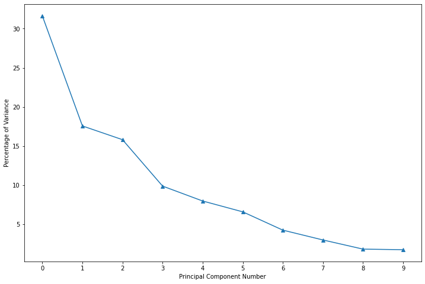

```python
varPercentage = pca.explained_variance_ratio_*100
fig = plt.figure(figsize=(12,8))
ax = fig.add_subplot(111)
ax.plot(range(10), varPercentage[:], marker='^')
plt.xlabel('Principal Component Number')
plt.ylabel('Percentage of Variance')
plt.xticks(range(10))
plt.show()
```

```python
sum(pca.explained_variance_ratio_[:3])
```

```
0.6499581229572469
```

```python
sum(pca.explained_variance_ratio_[:4])
```

```
0.748460990005608
```